# Final

**Scatter and Line Graph Plot, Boxplot, Finding Outliers, Outlier Value Table, Quartile Maths, Smoothing, SIRD Model**

```python
#importing python libraries
import numpy as np # numpy library used for mathematical operations on arrays such as trigonometric, statistical, and algebraic routines
import pandas as pd # pandas library used for data cleaning and analysis
import matplotlib.pyplot as plt # matplotlib library used for data visualization and graphical plotting
import math # math library used for math function
import plotly.graph_objects as go # library used for modified boxplot

from google.colab import drive # library used for mounting the Google Drive to Google Colab
from scipy.signal import savgol_filter # library used for applying Savitzky-Golay filter
from scipy import integrate, optimize # library used for optimization algorithms in SIRD Model Code
```

```python
drive.mount('/content/drive') #for mounting the Google Drive to Google Colab
```

```python
dataset = pd.read_excel("/content/drive/My Drive/CSE 499/Dataset (Covid-19 in Bangladesh) 15May21 - 15May22.xlsx") #read excel file from drive
dataset1 = pd.read_excel("/content/drive/My Drive/CSE 499/Dataset (Covid-19 in Bangladesh) 15May21 - 11Sept21.xlsx") #read excel file from drive
dataset2 = pd.read_excel("/content/drive/My Drive/CSE 499/Dataset (Covid-19 in Bangladesh) 12Sept21 - 9Jan22.xlsx") #read excel file from drive
dataset3 = pd.read_excel("/content/drive/My Drive/CSE 499/Dataset (Covid-19 in Bangladesh) 10Jan22 - 15May22.xlsx") #read excel file from drive
dataset #display excel file data
```

|  | Reporting Date | Days since the first case | Infected (Cumulative) | Infected (Last 24 Hours) | Growth in 24 hours (In numbers) | Growth Factor (24 hours) | Growth Factor (Cumulative) | Deaths (Cumulative) | Deaths (Last 24 Hours) | Death Rate (%) | ... | Active Cases | Growth Factor of Active Cases | Tested (Cumulative) | Tested (Last 24 Hours) | Transmission Type | Tests/Million | Infected/Million | Deaths/Million | Recoveries/Million | Cases/100 Tests |
| --- | --- | --- | --- | --- | --- | --- | --- | --- | --- | --- | --- | --- | --- | --- | --- | --- | --- | --- | --- | --- | --- |
| 0 | 2021-05-15 | 434 | 779796 | 261 | -587 | 0.307783 | 1.000335 | 12124 | 22 | 1.554766 | ... | 45283 | 0.984242 | 5703747 | 3758 | Community | 34494.992440 | 4716.032658 | 73.769395 | 4395.430484 | 13.671644 |
| 1 | 2021-05-16 | 435 | 780159 | 363 | 102 | 1.390805 | 1.000466 | 12149 | 25 | 1.557247 | ... | 45020 | 0.994192 | 5709177 | 5430 | Community | 34527.831872 | 4718.228001 | 73.921509 | 4399.087314 | 13.664999 |
| 2 | 2021-05-17 | 436 | 780857 | 698 | 335 | 1.922865 | 1.000895 | 12181 | 32 | 1.559953 | ... | 44628 | 0.991293 | 5719524 | 10347 | Community | 34590.408225 | 4722.449350 | 74.116215 | 4405.524795 | 13.652482 |
| 3 | 2021-05-18 | 437 | 782129 | 1272 | 574 | 1.822350 | 1.001629 | 12211 | 30 | 1.561251 | ... | 44755 | 1.002846 | 5736379 | 16855 | Community | 34692.343514 | 4730.142123 | 74.298753 | 4412.309096 | 13.634542 |
| 4 | 2021-05-19 | 438 | 783737 | 1608 | 336 | 1.264151 | 1.002056 | 12248 | 37 | 1.562769 | ... | 44403 | 0.992135 | 5756907 | 20528 | Community | 34816.492289 | 4739.866949 | 74.523882 | 4424.009735 | 13.613855 |
| ... | ... | ... | ... | ... | ... | ... | ... | ... | ... | ... | ... | ... | ... | ... | ... | ... | ... | ... | ... | ... | ... |
| 361 | 2022-05-11 | 795 | 1952888 | 33 | 7 | 1.269231 | 1.000017 | 29127 | 0 | 1.491483 | ... | 24327 | 0.991199 | 14028144 | 6182 | Community | 84839.092833 | 11810.631993 | 177.225434 | 11557.249772 | 13.921214 |
| 362 | 2022-05-12 | 796 | 1952939 | 51 | 18 | 1.545455 | 1.000026 | 29127 | 0 | 1.491444 | ... | 24087 | 0.990134 | 14033880 | 5736 | Community | 84873.782885 | 11810.940429 | 177.225434 | 11559.020383 | 13.915888 |
| 363 | 2022-05-13 | 797 | 1952957 | 18 | -33 | 0.352941 | 1.000009 | 29127 | 0 | 1.491431 | ... | 24078 | 0.999626 | 14037884 | 4004 | Community | 84897.998186 | 11811.049289 | 177.225434 | 11559.184667 | 13.912047 |
| 364 | 2022-05-14 | 798 | 1952979 | 22 | 4 | 1.222222 | 1.000011 | 29127 | 0 | 1.491414 | ... | 23580 | 0.979317 | 14041849 | 3965 | Community | 84921.977623 | 11811.182340 | 177.225434 | 11562.348646 | 13.908275 |
| 365 | 2022-05-15 | 799 | 1953012 | 33 | 11 | 1.500000 | 1.000017 | 29127 | 0 | 1.491389 | ... | 23344 | 0.989992 | 14045667 | 3818 | Community | 84945.068037 | 11811.381917 | 177.225434 | 11563.985397 | 13.904729 |

366 rows × 23 columns

```python
dataset.info() #information of excel file data
dataset.describe() #description of excel file data
```

```
<class 'pandas.core.frame.DataFrame'>
RangeIndex: 366 entries, 0 to 365
Data columns (total 23 columns):
 #   Column                           Non-Null Count  Dtype
---  ------                           --------------  -----
 0   Reporting Date                   366 non-null    datetime64[ns]
 1   Days since the first case        366 non-null    int64
 2   Infected (Cumulative)            366 non-null    int64
 3   Infected (Last 24 Hours)         366 non-null    int64
 4   Growth in 24 hours (In numbers)  366 non-null    int64
 5   Growth Factor (24 hours)         364 non-null    float64
 6   Growth Factor (Cumulative)       366 non-null    float64
 7   Deaths (Cumulative)              366 non-null    int64
 8   Deaths (Last 24 Hours)           366 non-null    int64
 9   Death Rate (%)                   366 non-null    float64
 10  Recovered (Cumulative)           366 non-null    int64
 11  Recovered (Last 24 Hours)        360 non-null    float64
 12  Recovery Rate (%)                366 non-null    float64
 13  Active Cases                     366 non-null    int64
 14  Growth Factor of Active Cases    366 non-null    float64
 15  Tested (Cumulative)              366 non-null    int64
 16  Tested (Last 24 Hours)           366 non-null    int64
 17  Transmission Type                366 non-null    object
 18  Tests/Million                    366 non-null    float64
 19  Infected/Million                 366 non-null    float64
 20  Deaths/Million                   366 non-null    float64
 21  Recoveries/Million               366 non-null    float64
 22  Cases/100 Tests                  366 non-null    float64
dtypes: datetime64[ns](1), float64(11), int64(10), object(1)
memory usage: 65.9+ KB
```

|  | Days since the first case | Infected (Cumulative) | Infected (Last 24 Hours) | Growth in 24 hours (In numbers) | Growth Factor (24 hours) | Growth Factor (Cumulative) | Deaths (Cumulative) | Deaths (Last 24 Hours) | Death Rate (%) | Recovered (Cumulative) | ... | Recovery Rate (%) | Active Cases | Growth Factor of Active Cases | Tested (Cumulative) | Tested (Last 24 Hours) | Tests/Million | Infected/Million | Deaths/Million | Recoveries/Million | Cases/100 Tests |
| --- | --- | --- | --- | --- | --- | --- | --- | --- | --- | --- | --- | --- | --- | --- | --- | --- | --- | --- | --- | --- | --- |
| count | 366.000000 | 3.660000e+02 | 366.000000 | 366.000000 | 364.000000 | 366.000000 | 366.000000 | 366.000000 | 366.000000 | 3.660000e+02 | ... | 366.000000 | 366.000000 | 366.000000 | 3.660000e+02 | 366.000000 | 366.000000 | 366.000000 | 366.000000 | 366.000000 | 366.000000 |
| mean | 616.500000 | 1.528192e+06 | 3206.221311 | -2.226776 | 1.025946 | 1.002519 | 25053.508197 | 46.516393 | 1.645086 | 1.445573e+06 | ... | 94.202145 | 57564.811475 | 0.999302 | 1.041847e+07 | 22802.398907 | 63008.601741 | 9242.162477 | 152.439965 | 8795.699701 | 14.718063 |
| std | 105.799338 | 3.659886e+05 | 4343.699063 | 990.010588 | 0.342430 | 0.003498 | 5647.699811 | 70.708574 | 0.115055 | 3.675349e+05 | ... | 4.034839 | 57227.855751 | 0.048755 | 2.643658e+06 | 11988.439106 | 15988.256829 | 2213.417876 | 34.363856 | 2236.293636 | 1.044918 |
| min | 434.000000 | 7.797960e+05 | 0.000000 | -5062.000000 | 0.000000 | 1.000000 | 12124.000000 | 0.000000 | 1.491389 | 7.223890e+05 | ... | 84.336218 | 6108.000000 | 0.760030 | 5.703747e+06 | 0.000000 | 34494.992440 | 4716.032658 | 73.769395 | 4395.430484 | 13.387857 |
| 25% | 525.250000 | 1.413889e+06 | 239.000000 | -141.250000 | 0.879647 | 1.000151 | 24034.750000 | 2.000000 | 1.509704 | 1.285124e+06 | ... | 92.152782 | 10383.000000 | 0.977266 | 8.384968e+06 | 16143.500000 | 50710.421832 | 8550.885999 | 146.241253 | 7819.432613 | 13.953372 |
| 50% | 616.500000 | 1.572390e+06 | 1035.500000 | 2.000000 | 1.006337 | 1.000709 | 27920.000000 | 12.000000 | 1.651128 | 1.537363e+06 | ... | 96.164855 | 40434.500000 | 0.991728 | 1.058614e+07 | 20538.500000 | 64022.615664 | 9509.461748 | 169.881351 | 9354.201399 | 14.399450 |
| 75% | 707.750000 | 1.908454e+06 | 4734.000000 | 101.750000 | 1.157063 | 1.003671 | 28812.000000 | 47.750000 | 1.769676 | 1.676314e+06 | ... | 97.567175 | 81214.000000 | 1.008696 | 1.298708e+07 | 29842.250000 | 78542.984578 | 11541.908074 | 175.308792 | 10199.657743 | 15.421186 |
| max | 799.000000 | 1.953012e+06 | 16230.000000 | 5475.000000 | 4.750000 | 1.013584 | 29127.000000 | 264.000000 | 1.775822 | 1.900541e+06 | ... | 97.838574 | 229271.000000 | 1.189562 | 1.404567e+07 | 55284.000000 | 84945.068037 | 11811.381917 | 177.225434 | 11563.985397 | 16.907256 |

8 rows × 21 columns

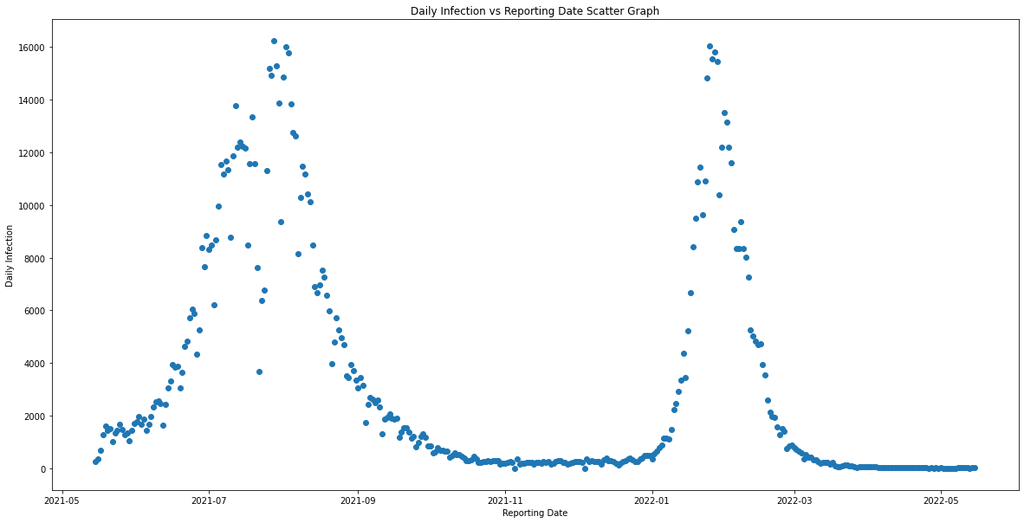

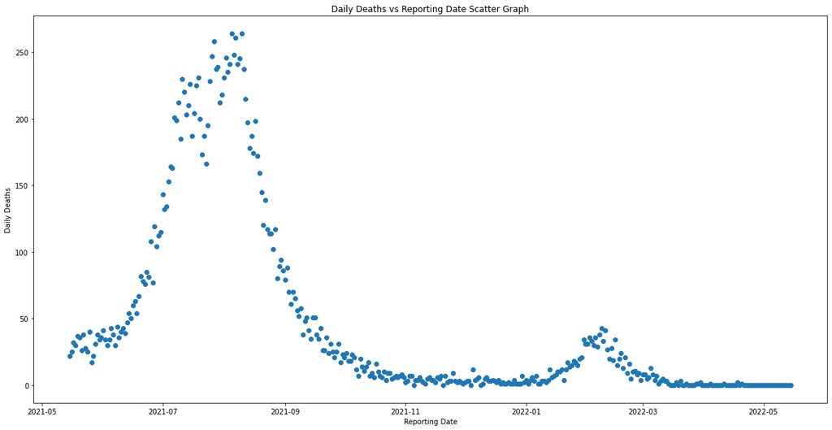

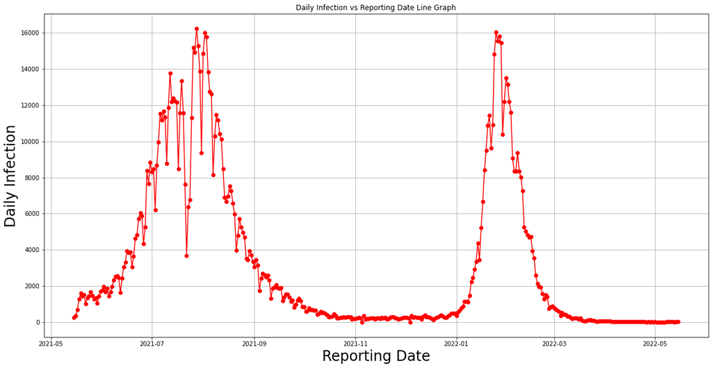

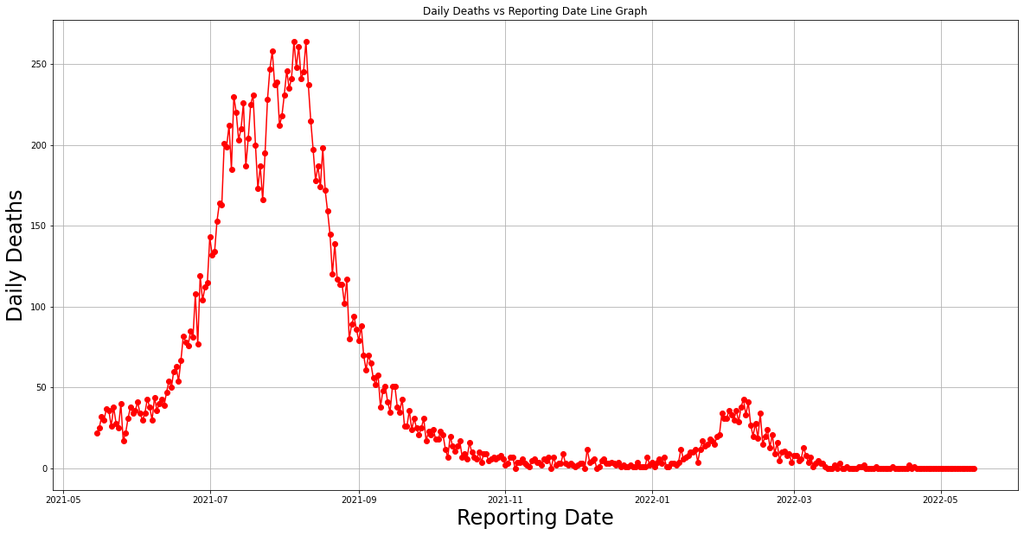

```python
# create a figure and axis
fig, ax = plt.subplots(figsize = (20, 10))
fig1, ax1 = plt.subplots(figsize = (20, 10))
fig2, ax2 = plt.subplots(figsize = (20, 10))
fig3, ax3 = plt.subplots(figsize = (20, 10))

# draw scatter graph
ax.scatter(x=dataset['Reporting Date'], y=dataset['Infected (Last 24 Hours)'])# scatter graph of Infected (Last 24 Hours) vs Reporting Date
ax1.scatter(x=dataset['Reporting Date'], y=dataset['Deaths (Last 24 Hours)']) # scatter graph of Deaths (Last 24 Hours) vs Reporting Date

# set a title and labels of Infected (Last 24 Hours) vs Reporting Date scatter graph
ax.set_title('Daily Infection vs Reporting Date Scatter Graph') # set title
ax.set_xlabel('Reporting Date') # label of x-axis
ax.set_ylabel('Daily Infection') # label of y-axis

# set a title and labels of Deaths (Last 24 Hours) vs Reporting Date scatter graph
ax1.set_title('Daily Deaths vs Reporting Date Scatter Graph') # set title
ax1.set_xlabel('Reporting Date') # label of x-axis
ax1.set_ylabel('Daily Deaths') # label of y-axis

# plot Infected (Last 24 Hours) vs Reporting Date line graph
ax2.plot(dataset['Reporting Date'], dataset['Infected (Last 24 Hours)'], color='red', marker='o')

# set a title and labels of Infected (Last 24 Hours) vs Reporting Date line graph
ax2.set_title('Daily Infection vs Reporting Date Line Graph') # set title
ax2.set_xlabel('Reporting Date', fontsize=24) # label of x-axis
ax2.set_ylabel('Daily Infection', fontsize=24) # label of y-axis
ax2.grid(True) #show grid line on graph

# plot Deaths (Last 24 Hours) vs Reporting Date line graph
ax3.plot(dataset['Reporting Date'], dataset['Deaths (Last 24 Hours)'], color='red', marker='o')

# set a title and labels of Deaths (Last 24 Hours) vs Reporting Date line graph
ax3.set_title('Daily Deaths vs Reporting Date Line Graph') # set title
ax3.set_xlabel('Reporting Date', fontsize=24) # label of x-axis
ax3.set_ylabel('Daily Deaths', fontsize=24) # label of y-axis
ax3.grid(True) #show grid line on graph
```

**Identifying Outliers of Infections**

```python
first120days = dataset1['Infected (Last 24 Hours)']

fig1 = go.Figure()

fig1.add_trace(go.Box(x=first120days, name='',
                marker_color = 'indianred'))

fig1.update_layout(
    xaxis=dict(title='Values from 15May21 - 11Sept21')
)
```

[interactive chart not shown]

```python
second120days = dataset2['Infected (Last 24 Hours)']

fig2 = go.Figure()

fig2.add_trace(go.Box(x=second120days, name='',
                marker_color = 'indianred'))

fig2.update_layout(
    xaxis=dict(title='Values from 12Sept21 - 9Jan22')
)
```

[interactive chart not shown]

```python
third126days = dataset3['Infected (Last 24 Hours)']

fig3 = go.Figure()

fig3.add_trace(go.Box(x=third126days, name='',
                marker_color = 'indianred'))

fig3.update_layout(
    xaxis=dict(title='Values from 10Jan22 - 15May22')
)
```

[interactive chart not shown]

**24 outliers found**

```python
print(np.where(dataset2['Infected (Last 24 Hours)']>1233)) #print outlier values Infected (Last 24 Hours) greater than 1233
print(np.where(dataset3['Infected (Last 24 Hours)']>10888)) #print outlier values Infected (Last 24 Hours) greater than 10888
```

```
(array([  0,   1,   2,   3,   4,   5,   7,   8,   9,  10,  16, 119]),)
(array([11, 13, 14, 15, 16, 17, 18, 20, 21, 22, 23, 24]),)
```

**Change Date Format**

```python
#dataset['Reporting Date'] = pd.to_datetime(dataset['Reporting Date']).dt.date
```

**12 Outliers are above 1233 and correspond date is shown on the y axis**

```python
limit = 1233 # maximum limit of boxplot
date_column = dataset2['Reporting Date'] # assign Reporting Date column from dataset into date_column variable
inf_column = dataset2['Infected (Last 24 Hours)'] # assign Infected (Last 24 Hours) column from dataset into inf_column variable
count_outlier_values = inf_column[inf_column > limit].count() # count the total number of outlier values of Infected (Last 24 Hours)
inf_outlier_date = date_column[inf_column > limit] # find infected outlier reporting date whose limit is greater than 11500
inf_outlier_values = inf_column[inf_column > limit] # find infected outlier values whose limit is greater than 11500

print('Total Outlier Values of Infection from 12Sept21 - 9Jan22:', count_outlier_values) # print the total number of outlier values of Infected (Last 24 Hours)
print('\nReporting Date      | Value') # print heading
print('-----------------------------') # print broken line
table_output = "\n".join("{} | {}".format(x, y) for x, y in zip(inf_outlier_date, inf_outlier_values)) # joining table
print(table_output) # print table output of outlier values of Infected (Last 24 Hours) after joining
```

```
Total Outlier Values of Infection from 12Sept21 - 9Jan22: 12

Reporting Date      | Value
-----------------------------
2021-09-12 00:00:00 | 1871
2021-09-13 00:00:00 | 1953
2021-09-14 00:00:00 | 2074
2021-09-15 00:00:00 | 1901
2021-09-16 00:00:00 | 1862
2021-09-17 00:00:00 | 1907
2021-09-19 00:00:00 | 1383
2021-09-20 00:00:00 | 1555
2021-09-21 00:00:00 | 1562
2021-09-22 00:00:00 | 1376
2021-09-28 00:00:00 | 1310
2022-01-09 00:00:00 | 1491
```

**12 Outliers are above 10888 and correspond date is shown on the y axis**

```python
limit = 10888 # maximum limit of boxplot
date_column = dataset3['Reporting Date'] # assign Reporting Date column from dataset into date_column variable
inf_column = dataset3['Infected (Last 24 Hours)'] # assign Infected (Last 24 Hours) column from dataset into inf_column variable
count_outlier_values = inf_column[inf_column > limit].count() # count the total number of outlier values of Infected (Last 24 Hours)
inf_outlier_date = date_column[inf_column > limit] # find infected outlier reporting date whose limit is greater than 11500
inf_outlier_values = inf_column[inf_column > limit] # find infected outlier values whose limit is greater than 11500

print('Total Outlier Values of Infection from from 10Jan22 - 15May22:', count_outlier_values) # print the total number of outlier values of Infected (Last 24 Hours)
print('\nReporting Date      | Value') # print heading
print('-----------------------------') # print broken line
table_output = "\n".join("{} | {}".format(x, y) for x, y in zip(inf_outlier_date, inf_outlier_values)) # joining table
print(table_output) # print table output of outlier values of Infected (Last 24 Hours) after joining
```

```
Total Outlier Values of Infection from from 10Jan22 - 15May22: 12

Reporting Date      | Value
-----------------------------
2022-01-21 00:00:00 | 11434
2022-01-23 00:00:00 | 10906
2022-01-24 00:00:00 | 14828
2022-01-25 00:00:00 | 16033
2022-01-26 00:00:00 | 15527
2022-01-27 00:00:00 | 15807
2022-01-28 00:00:00 | 15440
2022-01-30 00:00:00 | 12183
2022-01-31 00:00:00 | 13501
2022-02-01 00:00:00 | 13154
2022-02-02 00:00:00 | 12193
2022-02-03 00:00:00 | 11596
```

**First Quartile(Q1), Median, Third Quartile(Q3), Interquartile Range(IQR),Maximum & Minimum of Infection**

```python
minimum = min(dataset1['Infected (Last 24 Hours)']) # formula to find minimum value of Deaths
q1 = dataset1['Infected (Last 24 Hours)'].quantile(0.25) #percentile25(1st quartile of Deaths)
q3 = dataset1['Infected (Last 24 Hours)'].quantile(0.75) #percentile75(3rd quartile of Deaths)
iqr = q3 - q1 #formula of interquartile range of Deaths
lower_limit = (q1 - (1.5 * iqr)) # formula of lower limit of Deaths
upper_limit = (q3 + (1.5 * iqr)) # formula of upper limit of Deaths
maximum = max(dataset1['Infected (Last 24 Hours)']) # formula to find maximum value of Deaths

print('Lower Limit: ',lower_limit) # print lower limit of Deaths
print('Minimum Value: ',minimum) # print minimum value of Deaths
print('First Quartile(Q1): ',q1) #print 1st quartile of Deaths
print('Third Quartile(Q3): ',q3) #print 3rd quartile of Deaths
print('Upper Limit: ',upper_limit) # print upper limit of Deaths
print('Maximum: ',maximum) # print maximum value of Deaths
print('Interquartile Range(IQR): ',iqr) #print interquartile range of Deaths
```

```
Lower Limit:  -8920.5
Minimum Value:  261
First Quartile(Q1):  2434.5
Third Quartile(Q3):  10004.5
Upper Limit:  21359.5
Maximum:  16230
Interquartile Range(IQR):  7570.0
```

```python
minimum = min(dataset2['Infected (Last 24 Hours)']) # formula to find minimum value of Deaths
q1 = dataset2['Infected (Last 24 Hours)'].quantile(0.25) #percentile25(1st quartile of Deaths)
m = dataset2['Infected (Last 24 Hours)'].quantile(0.50) #percentile50(median of Deaths)
q3 = dataset2['Infected (Last 24 Hours)'].quantile(0.75) #percentile75(3rd quartile of Deaths)
iqr = q3 - q1 #formula of interquartile range of Deaths
lower_limit = (q1 - (1.5 * iqr)) # formula of lower limit of Deaths
upper_limit = (q3 + (1.5 * iqr)) # formula of upper limit of Deaths
maximum = max(dataset2['Infected (Last 24 Hours)']) # formula to find maximum value of Deaths

print('Lower Limit: ',lower_limit) # print lower limit of Deaths
print('Minimum Value: ',minimum) # print minimum value of Deaths
print('First Quartile(Q1): ',q1) #print 1st quartile of Deaths
print('Median: ',m) #print median of Deaths
print('Third Quartile(Q3): ',q3) #print 3rd quartile of Deaths
print('Upper Limit: ',upper_limit) # print upper limit of Deaths
print('Maximum: ',maximum) # print maximum value of Deaths
print('Interquartile Range(IQR): ',iqr) #print interquartile range of Deaths
```

```
Lower Limit:  -389.25
Minimum Value:  0
First Quartile(Q1):  243.75
Median:  309.0
Third Quartile(Q3):  665.75
Upper Limit:  1298.75
Maximum:  2074
Interquartile Range(IQR):  422.0
```

```python
minimum = min(dataset3['Infected (Last 24 Hours)']) # formula to find minimum value of Deaths
q1 = dataset3['Infected (Last 24 Hours)'].quantile(0.25) #percentile25(1st quartile of Deaths)
q3 = dataset3['Infected (Last 24 Hours)'].quantile(0.75) #percentile75(3rd quartile of Deaths)
iqr = q3 - q1 #formula of interquartile range of Deaths
lower_limit = (q1 - (1.5 * iqr)) # formula of lower limit of Deaths
upper_limit = (q3 + (1.5 * iqr)) # formula of upper limit of Deaths
maximum = max(dataset3['Infected (Last 24 Hours)']) # formula to find maximum value of Deaths

print('Lower Limit: ',lower_limit) # print lower limit of Deaths
print('Minimum Value: ',minimum) # print minimum value of Deaths
print('First Quartile(Q1): ',q1) #print 1st quartile of Deaths
print('Third Quartile(Q3): ',q3) #print 3rd quartile of Deaths
print('Upper Limit: ',upper_limit) # print upper limit of Deaths
print('Maximum: ',maximum) # print maximum value of Deaths
print('Interquartile Range(IQR): ',iqr) #print interquartile range of Deaths
```

```
Lower Limit:  -6304.875
Minimum Value:  4
First Quartile(Q1):  37.5
Third Quartile(Q3):  4265.75
Upper Limit:  10608.125
Maximum:  16033
Interquartile Range(IQR):  4228.25
```

**Identifying Outliers of Deaths**

```python
first120days = dataset1['Deaths (Last 24 Hours)']

fig4 = go.Figure()

fig4.add_trace(go.Box(x=first120days, name='',
                marker_color = 'indianred'))

fig4.update_layout(
    xaxis=dict(title='Values from 15May21 - 11Sept21')
)
```

[interactive chart not shown]

```python
second120days = dataset2['Deaths (Last 24 Hours)']

fig5 = go.Figure()

fig5.add_trace(go.Box(x=second120days, name='',
                marker_color = 'indianred'))

fig5.update_layout(
    xaxis=dict(title='Values from 12Sept21 - 9Jan22')
)
```

[interactive chart not shown]

```python
third126days = dataset3['Deaths (Last 24 Hours)']

fig6 = go.Figure()

fig6.add_trace(go.Box(x=third126days, name='',
                marker_color = 'indianred'))

fig6.update_layout(
    xaxis=dict(title='Values from 10Jan22 - 15May22')
)
```

[interactive chart not shown]

**20 outliers found**

```python
print(np.where(dataset2['Deaths (Last 24 Hours)']>26)) #print outlier values Deaths (Last 24 Hours) greater than 26
print(np.where(dataset3['Deaths (Last 24 Hours)']>31)) #print outlier values Deaths (Last 24 Hours) greater than 31
```

```
(array([ 0,  1,  2,  3,  4,  5,  6,  7, 10, 12, 16]),)
(array([20, 23, 24, 26, 28, 29, 30, 31, 36]),)
```

**11 Outliers are above 26 and correspond date is shown on the y axis**

```python
limit = 26 # maximum limit of boxplot
date_column = dataset2['Reporting Date'] # assign Reporting Date column from dataset into date_column variable
dth_column = dataset2['Deaths (Last 24 Hours)'] # assign Deaths (Last 24 Hours) column from dataset into dth_column variable
count_outlier_values = dth_column[dth_column > limit].count() # count the total number of outlier values of Deaths (Last 24 Hours)
dth_outlier_date = date_column[dth_column > limit] # find deaths outlier reporting date whose limit is greater than 120
dth_outlier_values = dth_column[dth_column > limit] # find deaths outlier values whose limit is greater than 120

print('Total Outlier Values of Deaths from 12Sept21 - 9Jan22: ', count_outlier_values) # print the total number of outlier values of Deaths (Last 24 Hours)
print('\nReporting Date      | Value') # print heading
print('-----------------------------') # print broken line
table_output1 = "\n".join("{} | {}".format(x, y) for x, y in zip(dth_outlier_date, dth_outlier_values)) # joining table
print(table_output1) # print table output of outlier values of Deaths (Last 24 Hours) after joining
```

```
Total Outlier Values of Deaths from 12Sept21 - 9Jan22:  11

Reporting Date      | Value
-----------------------------
2021-09-12 00:00:00 | 51
2021-09-13 00:00:00 | 41
2021-09-14 00:00:00 | 35
2021-09-15 00:00:00 | 51
2021-09-16 00:00:00 | 51
2021-09-17 00:00:00 | 38
2021-09-18 00:00:00 | 35
2021-09-19 00:00:00 | 43
2021-09-22 00:00:00 | 36
2021-09-24 00:00:00 | 31
2021-09-28 00:00:00 | 31
```

**9 Outliers are above 31 and correspond date is shown on the y axis**

```python
limit = 31 # maximum limit of boxplot
date_column = dataset3['Reporting Date'] # assign Reporting Date column from dataset into date_column variable
dth_column = dataset3['Deaths (Last 24 Hours)'] # assign Deaths (Last 24 Hours) column from dataset into dth_column variable
count_outlier_values = dth_column[dth_column > limit].count() # count the total number of outlier values of Deaths (Last 24 Hours)
dth_outlier_date = date_column[dth_column > limit] # find deaths outlier reporting date whose limit is greater than 120
dth_outlier_values = dth_column[dth_column > limit] # find deaths outlier values whose limit is greater than 120

print('Total Outlier Values of Deaths from 10Jan22 - 15May22: ', count_outlier_values) # print the total number of outlier values of Deaths (Last 24 Hours)
print('\nReporting Date      | Value') # print heading
print('-----------------------------') # print broken line
table_output1 = "\n".join("{} | {}".format(x, y) for x, y in zip(dth_outlier_date, dth_outlier_values)) # joining table
print(table_output1) # print table output of outlier values of Deaths (Last 24 Hours) after joining
```

```
Total Outlier Values of Deaths from 10Jan22 - 15May22:  9

Reporting Date      | Value
-----------------------------
2022-01-30 00:00:00 | 34
2022-02-02 00:00:00 | 36
2022-02-03 00:00:00 | 33
2022-02-05 00:00:00 | 36
2022-02-07 00:00:00 | 38
2022-02-08 00:00:00 | 43
2022-02-09 00:00:00 | 33
2022-02-10 00:00:00 | 41
2022-02-15 00:00:00 | 34
```

**First Quartile(Q1), Median, Third Quartile(Q3), Interquartile Range(IQR),Maximum & Minimum of Deaths**

```python
minimum = min(dataset1['Deaths (Last 24 Hours)']) # formula to find minimum value of Deaths
q1 = dataset1['Deaths (Last 24 Hours)'].quantile(0.25) #percentile25(1st quartile of Deaths)
q3 = dataset1['Deaths (Last 24 Hours)'].quantile(0.75) #percentile75(3rd quartile of Deaths)
iqr = q3 - q1 #formula of interquartile range of Deaths
lower_limit = (q1 - (1.5 * iqr)) # formula of lower limit of Deaths
upper_limit = (q3 + (1.5 * iqr)) # formula of upper limit of Deaths
maximum = max(dataset1['Deaths (Last 24 Hours)']) # formula to find maximum value of Deaths

print('Lower Limit: ',lower_limit) # print lower limit of Deaths
print('Minimum Value: ',minimum) # print minimum value of Deaths
print('First Quartile(Q1): ',q1) #print 1st quartile of Deaths
print('Third Quartile(Q3): ',q3) #print 3rd quartile of Deaths
print('Upper Limit: ',upper_limit) # print upper limit of Deaths
print('Maximum: ',maximum) # print maximum value of Deaths
print('Interquartile Range(IQR): ',iqr) #print interquartile range of Deaths
```

```
Lower Limit:  -183.25
Minimum Value:  17
First Quartile(Q1):  46.25
Third Quartile(Q3):  199.25
Upper Limit:  428.75
Maximum:  264
Interquartile Range(IQR):  153.0
```

```python
minimum = min(dataset2['Deaths (Last 24 Hours)']) # formula to find minimum value of Deaths
q1 = dataset2['Deaths (Last 24 Hours)'].quantile(0.25) #percentile25(1st quartile of Deaths)
q3 = dataset2['Deaths (Last 24 Hours)'].quantile(0.75) #percentile75(3rd quartile of Deaths)
iqr = q3 - q1 #formula of interquartile range of Deaths
lower_limit = (q1 - (1.5 * iqr)) # formula of lower limit of Deaths
upper_limit = (q3 + (1.5 * iqr)) # formula of upper limit of Deaths
maximum = max(dataset2['Deaths (Last 24 Hours)']) # formula to find maximum value of Deaths

print('Lower Limit: ',lower_limit) # print lower limit of Deaths
print('Minimum Value: ',minimum) # print minimum value of Deaths
print('First Quartile(Q1): ',q1) #print 1st quartile of Deaths
print('Third Quartile(Q3): ',q3) #print 3rd quartile of Deaths
print('Upper Limit: ',upper_limit) # print upper limit of Deaths
print('Maximum: ',maximum) # print maximum value of Deaths
print('Interquartile Range(IQR): ',iqr) #print interquartile range of Deaths
```

```
Lower Limit:  -11.25
Minimum Value:  0
First Quartile(Q1):  3.0
Third Quartile(Q3):  12.5
Upper Limit:  26.75
Maximum:  51
Interquartile Range(IQR):  9.5
```

```python
minimum = min(dataset3['Deaths (Last 24 Hours)']) # formula to find minimum value of Deaths
q1 = dataset3['Deaths (Last 24 Hours)'].quantile(0.25) #percentile25(1st quartile of Deaths)
q3 = dataset3['Deaths (Last 24 Hours)'].quantile(0.75) #percentile75(3rd quartile of Deaths)
iqr = q3 - q1 #formula of interquartile range of Deaths
lower_limit = (q1 - (1.5 * iqr)) # formula of lower limit of Deaths
upper_limit = (q3 + (1.5 * iqr)) # formula of upper limit of Deaths
maximum = max(dataset3['Deaths (Last 24 Hours)']) # formula to find maximum value of Deaths

print('Lower Limit: ',lower_limit) # print lower limit of Deaths
print('Minimum Value: ',minimum) # print minimum value of Deaths
print('First Quartile(Q1): ',q1) #print 1st quartile of Deaths
print('Third Quartile(Q3): ',q3) #print 3rd quartile of Deaths
print('Upper Limit: ',upper_limit) # print upper limit of Deaths
print('Maximum: ',maximum) # print maximum value of Deaths
print('Interquartile Range(IQR): ',iqr) #print interquartile range of Deaths
```

```
Lower Limit:  -19.125
Minimum Value:  0
First Quartile(Q1):  0.0
Third Quartile(Q3):  12.75
Upper Limit:  31.875
Maximum:  43
Interquartile Range(IQR):  12.75
```

**Smoothing on Infection with Polynomial Order 3**

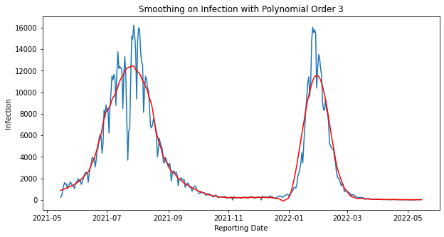

```python
x1 = dataset['Reporting Date'] # assign Reporting Date column from dataset into x1 variable
y1 = dataset['Infected (Last 24 Hours)'] # assign Infected (Last 24 Hours) column from dataset into y1 variable
yhat1 = savgol_filter(y1, 51, 3) # applying savgol filter on Infected (Last 24 Hours) with window size 51, polynomial order 3

fig4, ax4 = plt.subplots(figsize = (10, 5)) # create a figure and axis
ax4.set_title('Smoothing on Infection with Polynomial Order 3') # set title
ax4.set_xlabel('Reporting Date') # label of x-axis
ax4.set_ylabel('Infection') # label of y-axis

plt.plot(x1,y1) # Infection vs Reporting Date graph
plt.plot(x1,yhat1, color='red') # smoothened value vs Reporting Date graph after applying savgol filter on it
plt.show() # show graph
```

**Table with Smoothened Cumulative of Infection vs Reporting Date graph for Polynomial Order 3**

```
Reporting Date      | Infected (Last 24 Hours) | Smoothened Value | Smoothened Cumulative
------------------------------------------------------------------------------------------------
2021-05-15 00:00:00 |        261               | 880              | 880
2021-05-16 00:00:00 |        363               | 921              | 1801
2021-05-17 00:00:00 |        698               | 960              | 2762
2021-05-18 00:00:00 |        1272               | 998              | 3761
2021-05-19 00:00:00 |        1608               | 1035              | 4797
2021-05-20 00:00:00 |        1457               | 1072              | 5869
2021-05-21 00:00:00 |        1504               | 1108              | 6978
2021-05-22 00:00:00 |        1028               | 1145              | 8124
2021-05-23 00:00:00 |        1354               | 1182              | 9307
2021-05-24 00:00:00 |        1441               | 1221              | 10528
2021-05-25 00:00:00 |        1675               | 1261              | 11790
2021-05-26 00:00:00 |        1497               | 1303              | 13093
2021-05-27 00:00:00 |        1292               | 1348              | 14441
2021-05-28 00:00:00 |        1358               | 1395              | 15837
2021-05-29 00:00:00 |        1043               | 1446              | 17283
2021-05-30 00:00:00 |        1444               | 1500              | 18783
2021-05-31 00:00:00 |        1710               | 1558              | 20342
2021-06-01 00:00:00 |        1765               | 1621              | 21963
2021-06-02 00:00:00 |        1988               | 1689              | 23653
2021-06-03 00:00:00 |        1687               | 1762              | 25415
2021-06-04 00:00:00 |        1887               | 1841              | 27257
2021-06-05 00:00:00 |        1447               | 1926              | 29184
2021-06-06 00:00:00 |        1676               | 2018              | 31203
2021-06-07 00:00:00 |        1970               | 2117              | 33321
2021-06-08 00:00:00 |        2322               | 2224              | 35545
2021-06-09 00:00:00 |        2537               | 2338              | 37884
2021-06-10 00:00:00 |        2576               | 2428              | 40312
2021-06-11 00:00:00 |        2454               | 2499              | 42812
2021-06-12 00:00:00 |        1637               | 2617              | 45429
2021-06-13 00:00:00 |        2436               | 2765              | 48194
2021-06-14 00:00:00 |        3050               | 2959              | 51154
2021-06-15 00:00:00 |        3319               | 3243              | 54398
2021-06-16 00:00:00 |        3956               | 3454              | 57852
2021-06-17 00:00:00 |        3840               | 3623              | 61475
2021-06-18 00:00:00 |        3883               | 3873              | 65349
2021-06-19 00:00:00 |        3057               | 4142              | 69491
2021-06-20 00:00:00 |        3641               | 4441              | 73933
2021-06-21 00:00:00 |        4636               | 4754              | 78687
```

[output cut: 313 more lines]

```
2022-05-01 00:00:00 |        25               | 19              | 1173779
2022-05-02 00:00:00 |        10               | 19              | 1173798
2022-05-03 00:00:00 |        7               | 19              | 1173817
2022-05-04 00:00:00 |        10               | 19              | 1173837
2022-05-05 00:00:00 |        4               | 19              | 1173857
2022-05-06 00:00:00 |        19               | 20              | 1173877
2022-05-07 00:00:00 |        10               | 20              | 1173898
2022-05-08 00:00:00 |        23               | 21              | 1173919
2022-05-09 00:00:00 |        30               | 22              | 1173942
2022-05-10 00:00:00 |        26               | 23              | 1173965
2022-05-11 00:00:00 |        33               | 24              | 1173990
2022-05-12 00:00:00 |        51               | 26              | 1174016
2022-05-13 00:00:00 |        18               | 27              | 1174044
2022-05-14 00:00:00 |        22               | 29              | 1174074
2022-05-15 00:00:00 |        33               | 31              | 1174106
```

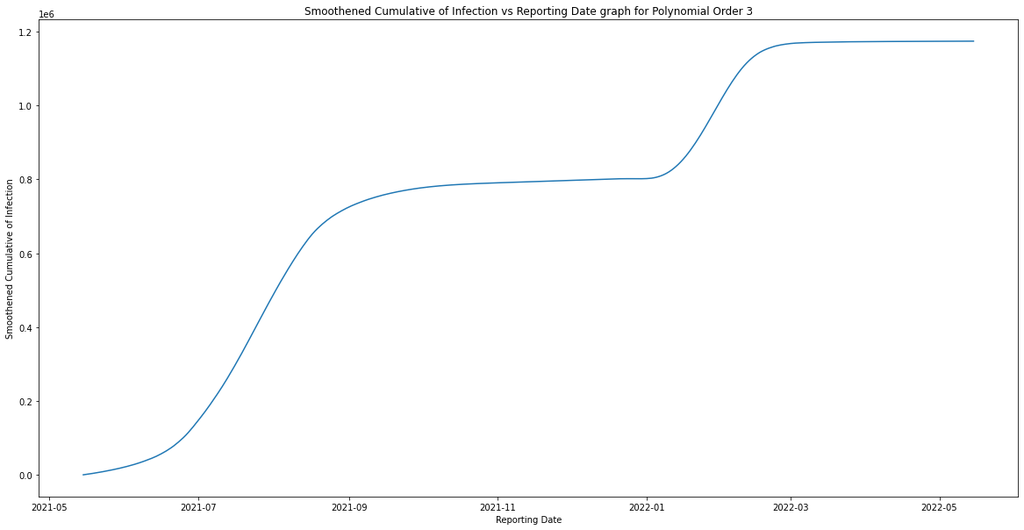

```python
c_list=[] # assign an empty array of name c_list(smoothened cumulative list)
y_hat=[] # assign an empty array of name y_hat(smoothened value)
y = 0  # variable y with value 0

for x in range(0,len(y1)): # for loop
    y = y + yhat1[x] # calculate Smoothened cumulative
    cr = math.trunc(y) # truncate and remove decimal points and round the value of Smoothened Cumulative
    c_list.append(cr) # insert the elements in the c_list array
    yhr = math.trunc(yhat1[x]) # truncate and remove decimal points and round the Smoothened Value
    y_hat.append(yhr) # insert the elements in the y_hat array

print('\nReporting Date      | Infected (Last 24 Hours) | Smoothened Value | Smoothened Cumulative') # print heading
print('------------------------------------------------------------------------------------------------') # print broken line
smooth_table_output = "\n".join("{} |        {}               | {}              | {}".format(a, b, c, d) for a, b, c, d in zip(x1, y1, y_hat, c_list)) # joining table
print(smooth_table_output) # print smooth_table_output after joining
fig5, ax5 = plt.subplots(figsize = (20, 10)) # create a figure and axis
ax5.set_title('Smoothened Cumulative of Infection vs Reporting Date graph for Polynomial Order 3') # set title
ax5.set_xlabel('Reporting Date') # label of x-axis
ax5.set_ylabel('Smoothened Cumulative of Infection') # label of y-axis
plt.plot(x1,c_list) # Plot Smoothened Cumulative vs Reporting Date graph
plt.show() # show graph
```

**Smoothing on Infection with Polynomial Order 4**

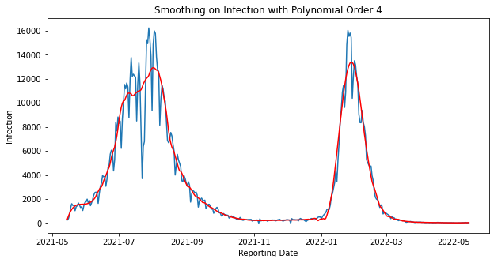

```python
x1 = dataset['Reporting Date'] # assign Reporting Date column from dataset into x1 variable
y1 = dataset['Infected (Last 24 Hours)'] # assign Infected (Last 24 Hours) column from dataset into y1 variable
yhat1 = savgol_filter(y1, 51, 4) # applying savgol filter on Infected (Last 24 Hours) with window size 51, polynomial order 4

fig6, ax6 = plt.subplots(figsize = (10, 5)) # create a figure and axis
ax6.set_title('Smoothing on Infection with Polynomial Order 4') # set title
ax6.set_xlabel('Reporting Date') # label of x-axis
ax6.set_ylabel('Infection') # label of y-axis

plt.plot(x1,y1) #Infected (Last 24 Hours) vs Reporting Date graph
plt.plot(x1,yhat1, color='red') #smoothened value vs Reporting Date graph after applying savgol filter on it
plt.show() # show graph
```

**Table with Smoothened Cumulative of Infection vs Reporting Date graph for Polynomial Order 4**

```
Reporting Date      | Infected (Last 24 Hours) | Smoothened Value | Smoothened Cumulative
------------------------------------------------------------------------------------------------
2021-05-15 00:00:00 |        261               | 315              | 315
2021-05-16 00:00:00 |        363               | 582              | 898
2021-05-17 00:00:00 |        698               | 806              | 1704
2021-05-18 00:00:00 |        1272               | 991              | 2696
2021-05-19 00:00:00 |        1608               | 1141              | 3837
2021-05-20 00:00:00 |        1457               | 1261              | 5099
2021-05-21 00:00:00 |        1504               | 1355              | 6454
2021-05-22 00:00:00 |        1028               | 1425              | 7880
2021-05-23 00:00:00 |        1354               | 1477              | 9358
2021-05-24 00:00:00 |        1441               | 1513              | 10871
2021-05-25 00:00:00 |        1675               | 1536              | 12407
2021-05-26 00:00:00 |        1497               | 1550              | 13958
2021-05-27 00:00:00 |        1292               | 1558              | 15516
2021-05-28 00:00:00 |        1358               | 1561              | 17078
2021-05-29 00:00:00 |        1043               | 1564              | 18643
2021-05-30 00:00:00 |        1444               | 1568              | 20211
2021-05-31 00:00:00 |        1710               | 1575              | 21787
2021-06-01 00:00:00 |        1765               | 1588              | 23376
2021-06-02 00:00:00 |        1988               | 1609              | 24985
2021-06-03 00:00:00 |        1687               | 1638              | 26623
2021-06-04 00:00:00 |        1887               | 1678              | 28302
2021-06-05 00:00:00 |        1447               | 1730              | 30032
2021-06-06 00:00:00 |        1676               | 1795              | 31828
2021-06-07 00:00:00 |        1970               | 1875              | 33704
2021-06-08 00:00:00 |        2322               | 1970              | 35674
2021-06-09 00:00:00 |        2537               | 2080              | 37755
2021-06-10 00:00:00 |        2576               | 2246              | 40001
2021-06-11 00:00:00 |        2454               | 2456              | 42457
2021-06-12 00:00:00 |        1637               | 2629              | 45087
2021-06-13 00:00:00 |        2436               | 2795              | 47883
2021-06-14 00:00:00 |        3050               | 2932              | 50815
2021-06-15 00:00:00 |        3319               | 3009              | 53825
2021-06-16 00:00:00 |        3956               | 3225              | 57050
2021-06-17 00:00:00 |        3840               | 3515              | 60565
2021-06-18 00:00:00 |        3883               | 3730              | 64296
2021-06-19 00:00:00 |        3057               | 3964              | 68260
2021-06-20 00:00:00 |        3641               | 4198              | 72458
2021-06-21 00:00:00 |        4636               | 4453              | 76912
```

[output cut: 313 more lines]

```
2022-05-01 00:00:00 |        25               | 18              | 1172977
2022-05-02 00:00:00 |        10               | 18              | 1172996
2022-05-03 00:00:00 |        7               | 18              | 1173014
2022-05-04 00:00:00 |        10               | 18              | 1173032
2022-05-05 00:00:00 |        4               | 18              | 1173050
2022-05-06 00:00:00 |        19               | 18              | 1173068
2022-05-07 00:00:00 |        10               | 19              | 1173088
2022-05-08 00:00:00 |        23               | 19              | 1173107
2022-05-09 00:00:00 |        30               | 21              | 1173129
2022-05-10 00:00:00 |        26               | 22              | 1173151
2022-05-11 00:00:00 |        33               | 24              | 1173175
2022-05-12 00:00:00 |        51               | 26              | 1173201
2022-05-13 00:00:00 |        18               | 28              | 1173230
2022-05-14 00:00:00 |        22               | 31              | 1173262
2022-05-15 00:00:00 |        33               | 35              | 1173297
```

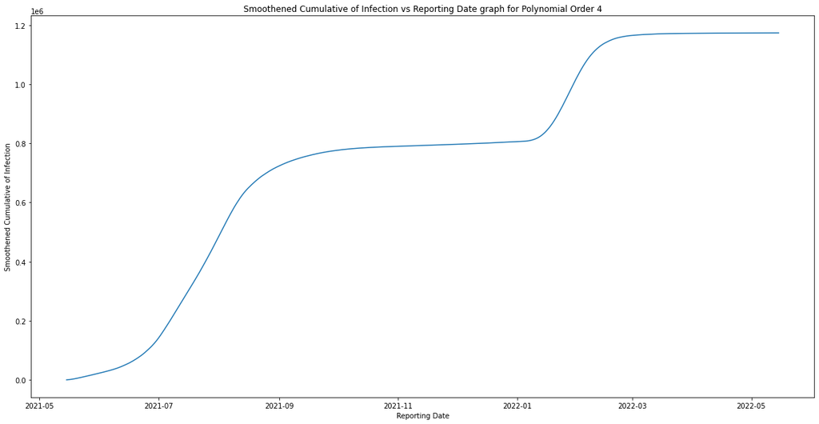

```python
c_list1=[] # assign an empty array of name c_list1(smoothened cumulative list)
y_hat1=[] # assign an empty array of name y_hat1(smoothened value)
y = 0 # variable y with value 0

for x in range(0,len(y1)): # for loop
    y = y + yhat1[x] # calculate Smoothened cumulative
    cr1 = math.trunc(y) # truncate and remove decimal points and round the value of Smoothened Cumulative
    c_list1.append(cr1) # insert the elements in the c_list1 array
    yhr1 = math.trunc(yhat1[x]) # truncate and remove decimal points and round the Smoothened Value
    y_hat1.append(yhr1) # insert the elements in the y_hat1 array

print('\nReporting Date      | Infected (Last 24 Hours) | Smoothened Value | Smoothened Cumulative') # print heading
print('------------------------------------------------------------------------------------------------') # print broken line
smooth_table_output1 = "\n".join("{} |        {}               | {}              | {}".format(a, b, c, d) for a, b, c, d in zip(x1, y1, y_hat1, c_list1)) # joining table
print(smooth_table_output1) # print smooth_table_output1 after joining
fig7, ax7 = plt.subplots(figsize = (20, 10)) #figure size
ax7.set_title('Smoothened Cumulative of Infection vs Reporting Date graph for Polynomial Order 4') # set title
ax7.set_xlabel('Reporting Date') # label of x-axis
ax7.set_ylabel('Smoothened Cumulative of Infection') # label of y-axis
plt.plot(x1,c_list1) #Plot Smoothened Cumulative vs Reporting Date graph
plt.show() # show graph
```

**Smoothing on Infection with Polynomial Order 5**

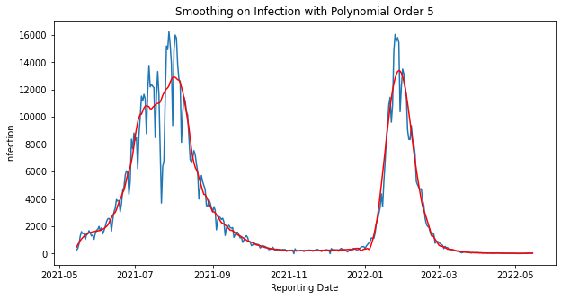

```python
x1 = dataset['Reporting Date'] # assign Reporting Date column from dataset into x1 variable
y1 = dataset['Infected (Last 24 Hours)'] # assign Infected (Last 24 Hours) column from dataset into y1 variable
yhat1 = savgol_filter(y1, 51, 5) # applying savgol filter on Infected (Last 24 Hours) with window size 51, polynomial order 5

fig8, ax8 = plt.subplots(figsize = (10, 5)) # create a figure and axis
ax8.set_title('Smoothing on Infection with Polynomial Order 5') # set title
ax8.set_xlabel('Reporting Date') # label of x-axis
ax8.set_ylabel('Infection') # label of y-axis

plt.plot(x1,y1) # Infected (Last 24 Hours) vs Reporting Date graph
plt.plot(x1,yhat1, color='red') # smoothened value vs Reporting Date graph after applying savgol filter on it
plt.show() # show graph
```

**Table with Smoothened Cumulative of Infection vs Reporting Date graph for Polynomial Order 5**

```
Reporting Date      | Infected (Last 24 Hours) | Smoothened Value | Smoothened Cumulative
------------------------------------------------------------------------------------------------
2021-05-15 00:00:00 |        261               | 465              | 465
2021-05-16 00:00:00 |        363               | 642              | 1108
2021-05-17 00:00:00 |        698               | 802              | 1910
2021-05-18 00:00:00 |        1272               | 944              | 2854
2021-05-19 00:00:00 |        1608               | 1069              | 3923
2021-05-20 00:00:00 |        1457               | 1178              | 5102
2021-05-21 00:00:00 |        1504               | 1271              | 6373
2021-05-22 00:00:00 |        1028               | 1349              | 7723
2021-05-23 00:00:00 |        1354               | 1415              | 9138
2021-05-24 00:00:00 |        1441               | 1468              | 10606
2021-05-25 00:00:00 |        1675               | 1511              | 12117
2021-05-26 00:00:00 |        1497               | 1544              | 13662
2021-05-27 00:00:00 |        1292               | 1571              | 15234
2021-05-28 00:00:00 |        1358               | 1592              | 16826
2021-05-29 00:00:00 |        1043               | 1609              | 18436
2021-05-30 00:00:00 |        1444               | 1624              | 20061
2021-05-31 00:00:00 |        1710               | 1640              | 21701
2021-06-01 00:00:00 |        1765               | 1657              | 23359
2021-06-02 00:00:00 |        1988               | 1678              | 25038
2021-06-03 00:00:00 |        1687               | 1705              | 26743
2021-06-04 00:00:00 |        1887               | 1739              | 28483
2021-06-05 00:00:00 |        1447               | 1783              | 30267
2021-06-06 00:00:00 |        1676               | 1837              | 32105
2021-06-07 00:00:00 |        1970               | 1904              | 34009
2021-06-08 00:00:00 |        2322               | 1984              | 35994
2021-06-09 00:00:00 |        2537               | 2080              | 38074
2021-06-10 00:00:00 |        2576               | 2246              | 40321
2021-06-11 00:00:00 |        2454               | 2456              | 42777
2021-06-12 00:00:00 |        1637               | 2629              | 45407
2021-06-13 00:00:00 |        2436               | 2795              | 48202
2021-06-14 00:00:00 |        3050               | 2932              | 51135
2021-06-15 00:00:00 |        3319               | 3009              | 54144
2021-06-16 00:00:00 |        3956               | 3225              | 57370
2021-06-17 00:00:00 |        3840               | 3515              | 60885
2021-06-18 00:00:00 |        3883               | 3730              | 64616
2021-06-19 00:00:00 |        3057               | 3964              | 68580
2021-06-20 00:00:00 |        3641               | 4198              | 72778
2021-06-21 00:00:00 |        4636               | 4453              | 77232
```

[output cut: 313 more lines]

```
2022-05-01 00:00:00 |        25               | 20              | 1173313
2022-05-02 00:00:00 |        10               | 19              | 1173333
2022-05-03 00:00:00 |        7               | 18              | 1173351
2022-05-04 00:00:00 |        10               | 17              | 1173369
2022-05-05 00:00:00 |        4               | 17              | 1173387
2022-05-06 00:00:00 |        19               | 17              | 1173404
2022-05-07 00:00:00 |        10               | 17              | 1173421
2022-05-08 00:00:00 |        23               | 17              | 1173439
2022-05-09 00:00:00 |        30               | 18              | 1173457
2022-05-10 00:00:00 |        26               | 20              | 1173477
2022-05-11 00:00:00 |        33               | 22              | 1173500
2022-05-12 00:00:00 |        51               | 24              | 1173525
2022-05-13 00:00:00 |        18               | 28              | 1173553
2022-05-14 00:00:00 |        22               | 33              | 1173587
2022-05-15 00:00:00 |        33               | 39              | 1173626
```

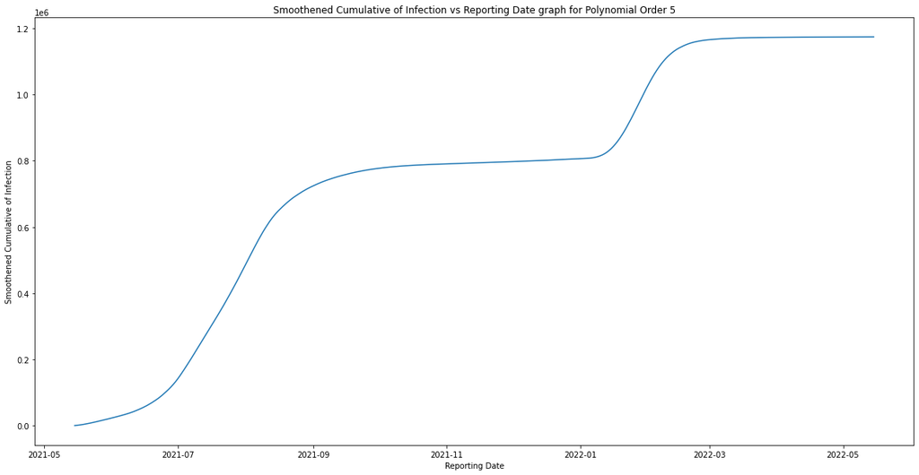

```python
c_list2=[] # assign an empty array of name c_list2(smoothened cumulative list)
y_hat2=[] # assign an empty array of name y_hat2(smoothened value)
y = 0 # variable y with value 0

for x in range(0,len(y1)): # for loop
    y = y + yhat1[x] # calculate Smoothened cumulative
    cr2 = math.trunc(y) # truncate and remove decimal points and round the value of Smoothened Cumulative
    c_list2.append(cr2) # insert the elements in the c_list2 array
    yhr2 = math.trunc(yhat1[x]) # truncate and remove decimal points and round the Smoothened Value
    y_hat2.append(yhr2) # insert the elements in the y_hat2 array

print('\nReporting Date      | Infected (Last 24 Hours) | Smoothened Value | Smoothened Cumulative') # print heading
print('------------------------------------------------------------------------------------------------') # print broken line
smooth_table_output2 = "\n".join("{} |        {}               | {}              | {}".format(a, b, c, d) for a, b, c, d in zip(x1, y1, y_hat2, c_list2)) # joining table
print(smooth_table_output2)# print smooth_table_output2 after joining
fig9, ax9 = plt.subplots(figsize = (20, 10)) # create a figure and axis
ax9.set_title('Smoothened Cumulative of Infection vs Reporting Date graph for Polynomial Order 5') # set title
ax9.set_xlabel('Reporting Date') # label of x-axis
ax9.set_ylabel('Smoothened Cumulative of Infection') # label of y-axis
plt.plot(x1,c_list2) # Plot Smoothened Cumulative vs Reporting Date graph
plt.show() # show graph
```

**Smoothing on Deaths with Polynomial Order 3**

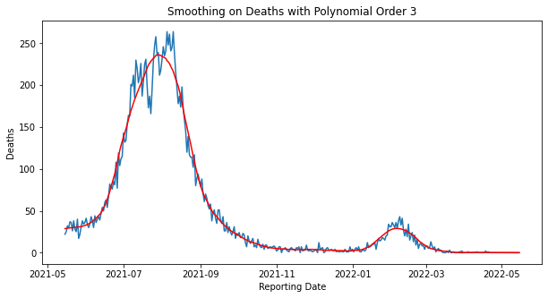

```python
x2 = dataset['Reporting Date'] # assign Reporting Date column from dataset into x2 variable
y2 = dataset['Deaths (Last 24 Hours)'] # assign Deaths (Last 24 Hours) column from dataset into y2 variable
yhat2 = savgol_filter(y2, 51, 3) # applying savgol filter on Deaths (Last 24 Hours) with window size 51, polynomial order 3

fig10, ax10 = plt.subplots(figsize = (10, 5)) # create a figure and axis
ax10.set_title('Smoothing on Deaths with Polynomial Order 3') # set title
ax10.set_xlabel('Reporting Date') # label of x-axis
ax10.set_ylabel('Deaths') # label of y-axis

plt.plot(x2,y2) # Deaths (Last 24 Hours) vs Reporting Date graph
plt.plot(x2,yhat2, color='red') # smoothened value vs Reporting Date graph after applying savgol filter on it
plt.show() # show graph
```

**Table with Smoothened Cumulative of Deaths vs Reporting Date graph for Polynomial Order 3**

```
Reporting Date      | Deaths (Last 24 Hours)  | Smoothened Value      | Smoothened Cumulative
------------------------------------------------------------------------------------------------
2021-05-15 00:00:00 |        22               | 28                    | 28
2021-05-16 00:00:00 |        25               | 28                    | 57
2021-05-17 00:00:00 |        32               | 29                    | 86
2021-05-18 00:00:00 |        30               | 29                    | 116
2021-05-19 00:00:00 |        37               | 29                    | 145
2021-05-20 00:00:00 |        36               | 29                    | 175
2021-05-21 00:00:00 |        26               | 29                    | 205
2021-05-22 00:00:00 |        38               | 29                    | 235
2021-05-23 00:00:00 |        28               | 30                    | 265
2021-05-24 00:00:00 |        25               | 30                    | 295
2021-05-25 00:00:00 |        40               | 30                    | 326
2021-05-26 00:00:00 |        17               | 30                    | 356
2021-05-27 00:00:00 |        22               | 30                    | 387
2021-05-28 00:00:00 |        31               | 31                    | 419
2021-05-29 00:00:00 |        38               | 31                    | 450
2021-05-30 00:00:00 |        34               | 31                    | 482
2021-05-31 00:00:00 |        36               | 32                    | 514
2021-06-01 00:00:00 |        41               | 32                    | 547
2021-06-02 00:00:00 |        34               | 33                    | 581
2021-06-03 00:00:00 |        30               | 34                    | 615
2021-06-04 00:00:00 |        34               | 35                    | 651
2021-06-05 00:00:00 |        43               | 36                    | 687
2021-06-06 00:00:00 |        38               | 37                    | 724
2021-06-07 00:00:00 |        30               | 38                    | 763
2021-06-08 00:00:00 |        44               | 39                    | 802
2021-06-09 00:00:00 |        36               | 41                    | 844
2021-06-10 00:00:00 |        40               | 42                    | 886
2021-06-11 00:00:00 |        43               | 44                    | 931
2021-06-12 00:00:00 |        39               | 45                    | 976
2021-06-13 00:00:00 |        47               | 47                    | 1024
2021-06-14 00:00:00 |        54               | 50                    | 1074
2021-06-15 00:00:00 |        50               | 53                    | 1128
2021-06-16 00:00:00 |        60               | 56                    | 1184
2021-06-17 00:00:00 |        63               | 59                    | 1244
2021-06-18 00:00:00 |        54               | 64                    | 1308
2021-06-19 00:00:00 |        67               | 68                    | 1376
2021-06-20 00:00:00 |        82               | 73                    | 1449
2021-06-21 00:00:00 |        78               | 78                    | 1528
```

[output cut: 313 more lines]

```
2022-05-01 00:00:00 |        0               | 0                    | 17037
2022-05-02 00:00:00 |        0               | 0                    | 17037
2022-05-03 00:00:00 |        0               | 0                    | 17037
2022-05-04 00:00:00 |        0               | 0                    | 17037
2022-05-05 00:00:00 |        0               | 0                    | 17037
2022-05-06 00:00:00 |        0               | 0                    | 17037
2022-05-07 00:00:00 |        0               | 0                    | 17037
2022-05-08 00:00:00 |        0               | 0                    | 17037
2022-05-09 00:00:00 |        0               | 0                    | 17037
2022-05-10 00:00:00 |        0               | 0                    | 17037
2022-05-11 00:00:00 |        0               | 0                    | 17037
2022-05-12 00:00:00 |        0               | 0                    | 17037
2022-05-13 00:00:00 |        0               | 0                    | 17037
2022-05-14 00:00:00 |        0               | 0                    | 17037
2022-05-15 00:00:00 |        0               | 0                    | 17037
```

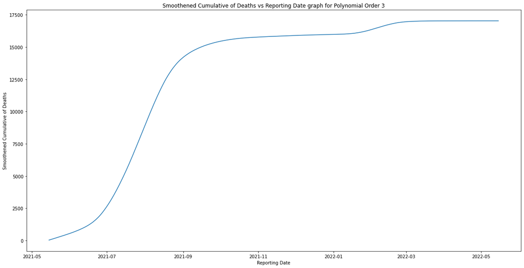

```python
c_list3=[] # assign an empty array of name c_list3(smoothened cumulative list)
y_hat3=[] # assign an empty array of name y_hat3(smoothened value)
y = 0 # variable y with value 0

for x in range(0,len(y1)): # for loop
    y = y + yhat2[x] # calculate Smoothened cumulative
    cr3 = math.trunc(y) # truncate and remove decimal points and round the value of Smoothened Cumulative
    c_list3.append(cr3) # insert the elements in the c_list3 array
    yhr3 = math.trunc(yhat2[x]) # truncate and remove decimal points and round the Smoothened Value
    y_hat3.append(yhr3) # insert the elements in the y_hat3 array

print('\nReporting Date      | Deaths (Last 24 Hours)  | Smoothened Value      | Smoothened Cumulative') # print heading
print('------------------------------------------------------------------------------------------------') # print broken line
smooth_table_output3 = "\n".join("{} |        {}               | {}                    | {}".format(a, b, c, d) for a, b, c, d in zip(x2, y2, y_hat3, c_list3)) # joining table
print(smooth_table_output3) # print smooth_table_output3 after joining
fig11, ax11 = plt.subplots(figsize = (20, 10)) # create a figure and axis
ax11.set_title('Smoothened Cumulative of Deaths vs Reporting Date graph for Polynomial Order 3') # set title
ax11.set_xlabel('Reporting Date') # label of x-axis
ax11.set_ylabel('Smoothened Cumulative of Deaths') # label of y-axis
plt.plot(x2,c_list3) # Plot Smoothened Cumulative vs Reporting Date graph
plt.show() #show graph
```

**Smoothing on Deaths with Polynomial Order 4**

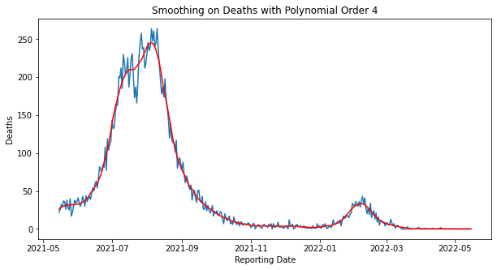

```python
x2 = dataset['Reporting Date'] # assign Reporting Date column from dataset into x2 variable
y2 = dataset['Deaths (Last 24 Hours)'] # assign Deaths (Last 24 Hours) column from dataset into y2 variable
yhat2 = savgol_filter(y2, 51, 4) # applying savgol filter on Deaths (Last 24 Hours) with window size 51, polynomial order 4

fig12, ax12 = plt.subplots(figsize = (10, 5)) # create a figure and axis
ax12.set_title('Smoothing on Deaths with Polynomial Order 4') # set title
ax12.set_xlabel('Reporting Date') # label of x-axis
ax12.set_ylabel('Deaths') # label of y-axis

plt.plot(x2,y2) # Deaths (Last 24 Hours) vs Reporting Date graph
plt.plot(x2,yhat2, color='red') # smoothened value vs Reporting Date graph after applying savgol filter on it
plt.show() # show graph
```

**Table with Smoothened Cumulative of Deaths vs Reporting Date graph for Polynomial Order 4**

```
Reporting Date      | Deaths (Last 24 Hours)  | Smoothened Value      | Smoothened Cumulative
------------------------------------------------------------------------------------------------
2021-05-15 00:00:00 |        22               | 26                    | 26
2021-05-16 00:00:00 |        25               | 27                    | 53
2021-05-17 00:00:00 |        32               | 28                    | 82
2021-05-18 00:00:00 |        30               | 29                    | 111
2021-05-19 00:00:00 |        37               | 30                    | 141
2021-05-20 00:00:00 |        36               | 30                    | 172
2021-05-21 00:00:00 |        26               | 30                    | 203
2021-05-22 00:00:00 |        38               | 31                    | 234
2021-05-23 00:00:00 |        28               | 31                    | 265
2021-05-24 00:00:00 |        25               | 31                    | 297
2021-05-25 00:00:00 |        40               | 31                    | 329
2021-05-26 00:00:00 |        17               | 31                    | 360
2021-05-27 00:00:00 |        22               | 31                    | 392
2021-05-28 00:00:00 |        31               | 31                    | 424
2021-05-29 00:00:00 |        38               | 32                    | 456
2021-05-30 00:00:00 |        34               | 32                    | 488
2021-05-31 00:00:00 |        36               | 32                    | 521
2021-06-01 00:00:00 |        41               | 32                    | 554
2021-06-02 00:00:00 |        34               | 33                    | 587
2021-06-03 00:00:00 |        30               | 33                    | 621
2021-06-04 00:00:00 |        34               | 34                    | 655
2021-06-05 00:00:00 |        43               | 35                    | 691
2021-06-06 00:00:00 |        38               | 36                    | 727
2021-06-07 00:00:00 |        30               | 37                    | 764
2021-06-08 00:00:00 |        44               | 38                    | 803
2021-06-09 00:00:00 |        36               | 40                    | 843
2021-06-10 00:00:00 |        40               | 42                    | 885
2021-06-11 00:00:00 |        43               | 44                    | 930
2021-06-12 00:00:00 |        39               | 47                    | 977
2021-06-13 00:00:00 |        47               | 49                    | 1026
2021-06-14 00:00:00 |        54               | 51                    | 1078
2021-06-15 00:00:00 |        50               | 52                    | 1131
2021-06-16 00:00:00 |        60               | 56                    | 1187
2021-06-17 00:00:00 |        63               | 58                    | 1246
2021-06-18 00:00:00 |        54               | 60                    | 1306
2021-06-19 00:00:00 |        67               | 63                    | 1370
2021-06-20 00:00:00 |        82               | 67                    | 1437
2021-06-21 00:00:00 |        78               | 70                    | 1508
```

[output cut: 313 more lines]

```
2022-05-01 00:00:00 |        0               | 0                    | 17026
2022-05-02 00:00:00 |        0               | 0                    | 17026
2022-05-03 00:00:00 |        0               | 0                    | 17026
2022-05-04 00:00:00 |        0               | 0                    | 17026
2022-05-05 00:00:00 |        0               | 0                    | 17026
2022-05-06 00:00:00 |        0               | 0                    | 17026
2022-05-07 00:00:00 |        0               | 0                    | 17026
2022-05-08 00:00:00 |        0               | 0                    | 17026
2022-05-09 00:00:00 |        0               | 0                    | 17025
2022-05-10 00:00:00 |        0               | 0                    | 17025
2022-05-11 00:00:00 |        0               | 0                    | 17025
2022-05-12 00:00:00 |        0               | 0                    | 17025
2022-05-13 00:00:00 |        0               | 0                    | 17025
2022-05-14 00:00:00 |        0               | 0                    | 17025
2022-05-15 00:00:00 |        0               | 0                    | 17025
```

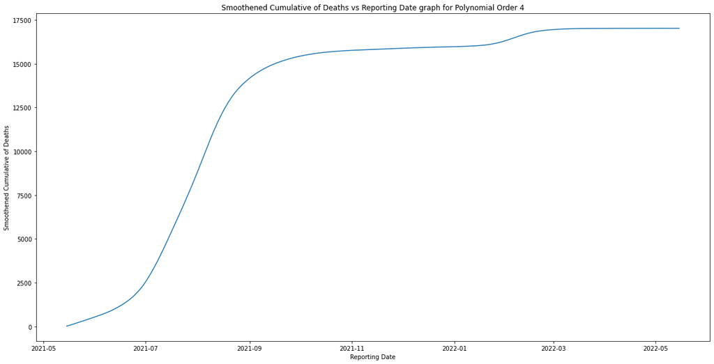

```python
c_list4=[] # assign an empty array of name c_list4(smoothened cumulative list)
y_hat4=[] # assign an empty array of name y_hat4(smoothened value)
y = 0 # variable y with value 0

for x in range(0,len(y1)): # for loop
    y = y + yhat2[x] # calculate Smoothened cumulative
    cr4 = math.trunc(y) # truncate and remove decimal points and round the value of Smoothened Cumulative
    c_list4.append(cr4) # insert the elements in the c_list4 array
    yhr4 = math.trunc(yhat2[x]) # truncate and remove decimal points and round the Smoothened Value
    y_hat4.append(yhr4) # insert the elements in the y_hat4 array

print('\nReporting Date      | Deaths (Last 24 Hours)  | Smoothened Value      | Smoothened Cumulative') # print heading
print('------------------------------------------------------------------------------------------------') # print broken line
smooth_table_output4 = "\n".join("{} |        {}               | {}                    | {}".format(a, b, c, d) for a, b, c, d in zip(x2, y2, y_hat4, c_list4)) # joining table
print(smooth_table_output4) # print smooth_table_output4 after joining
fig13, ax13 = plt.subplots(figsize = (20, 10)) # create a figure and axis
ax13.set_title('Smoothened Cumulative of Deaths vs Reporting Date graph for Polynomial Order 4') # set title
ax13.set_xlabel('Reporting Date') # label of x-axis
ax13.set_ylabel('Smoothened Cumulative of Deaths') # label of y-axis
plt.plot(x2,c_list4) # Plot Smoothened Cumulative vs Reporting Date graph
plt.show() # show graph
```

**Smoothing on Deaths with Polynomial Order 5**

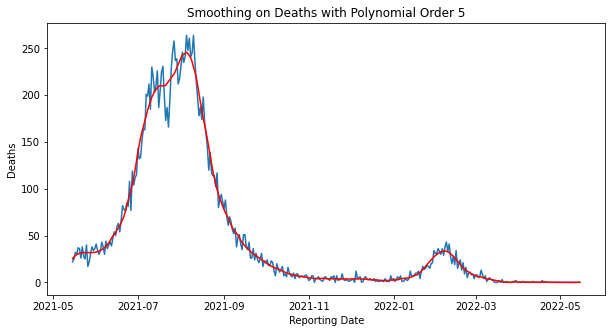

```python
x2 = dataset['Reporting Date'] # assign Reporting Date column from dataset into x2 variable
y2 = dataset['Deaths (Last 24 Hours)'] # assign Deaths (Last 24 Hours) column from dataset into y2 variable
yhat2 = savgol_filter(y2, 51, 5) # applying savgol filter on Deaths (Last 24 Hours) with window size 51, polynomial order 5

fig14, ax14 = plt.subplots(figsize = (10, 5)) # create a figure and axis
ax14.set_title('Smoothing on Deaths with Polynomial Order 5') # set title
ax14.set_xlabel('Reporting Date') # label of x-axis
ax14.set_ylabel('Deaths') # label of y-axis

plt.plot(x2,y2) # Deaths (Last 24 Hours) vs Reporting Date graph
plt.plot(x2,yhat2, color='red') # smoothened value vs Reporting Date graph after applying savgol filter on it
plt.show() # show graph
```

**Table with Smoothened Cumulative of Deaths vs Reporting Date graph for Polynomial Order 5**

```
Reporting Date      | Deaths (Last 24 Hours)  | Smoothened Value      | Smoothened Cumulative
------------------------------------------------------------------------------------------------
2021-05-15 00:00:00 |        22               | 25                    | 25
2021-05-16 00:00:00 |        25               | 27                    | 52
2021-05-17 00:00:00 |        32               | 28                    | 80
2021-05-18 00:00:00 |        30               | 29                    | 110
2021-05-19 00:00:00 |        37               | 30                    | 141
2021-05-20 00:00:00 |        36               | 31                    | 172
2021-05-21 00:00:00 |        26               | 31                    | 203
2021-05-22 00:00:00 |        38               | 31                    | 235
2021-05-23 00:00:00 |        28               | 31                    | 267
2021-05-24 00:00:00 |        25               | 31                    | 299
2021-05-25 00:00:00 |        40               | 31                    | 330
2021-05-26 00:00:00 |        17               | 31                    | 362
2021-05-27 00:00:00 |        22               | 31                    | 394
2021-05-28 00:00:00 |        31               | 31                    | 426
2021-05-29 00:00:00 |        38               | 31                    | 457
2021-05-30 00:00:00 |        34               | 31                    | 489
2021-05-31 00:00:00 |        36               | 32                    | 521
2021-06-01 00:00:00 |        41               | 32                    | 554
2021-06-02 00:00:00 |        34               | 32                    | 587
2021-06-03 00:00:00 |        30               | 33                    | 620
2021-06-04 00:00:00 |        34               | 34                    | 654
2021-06-05 00:00:00 |        43               | 34                    | 689
2021-06-06 00:00:00 |        38               | 36                    | 725
2021-06-07 00:00:00 |        30               | 37                    | 762
2021-06-08 00:00:00 |        44               | 38                    | 801
2021-06-09 00:00:00 |        36               | 40                    | 841
2021-06-10 00:00:00 |        40               | 42                    | 883
2021-06-11 00:00:00 |        43               | 44                    | 928
2021-06-12 00:00:00 |        39               | 47                    | 975
2021-06-13 00:00:00 |        47               | 49                    | 1024
2021-06-14 00:00:00 |        54               | 51                    | 1076
2021-06-15 00:00:00 |        50               | 52                    | 1129
2021-06-16 00:00:00 |        60               | 56                    | 1185
2021-06-17 00:00:00 |        63               | 58                    | 1244
2021-06-18 00:00:00 |        54               | 60                    | 1304
2021-06-19 00:00:00 |        67               | 63                    | 1368
2021-06-20 00:00:00 |        82               | 67                    | 1435
2021-06-21 00:00:00 |        78               | 70                    | 1506
```

[output cut: 313 more lines]

```
2022-05-01 00:00:00 |        0               | 0                    | 17024
2022-05-02 00:00:00 |        0               | 0                    | 17024
2022-05-03 00:00:00 |        0               | 0                    | 17024
2022-05-04 00:00:00 |        0               | 0                    | 17024
2022-05-05 00:00:00 |        0               | 0                    | 17024
2022-05-06 00:00:00 |        0               | 0                    | 17024
2022-05-07 00:00:00 |        0               | 0                    | 17024
2022-05-08 00:00:00 |        0               | 0                    | 17024
2022-05-09 00:00:00 |        0               | 0                    | 17024
2022-05-10 00:00:00 |        0               | 0                    | 17024
2022-05-11 00:00:00 |        0               | 0                    | 17024
2022-05-12 00:00:00 |        0               | 0                    | 17024
2022-05-13 00:00:00 |        0               | 0                    | 17024
2022-05-14 00:00:00 |        0               | 0                    | 17024
2022-05-15 00:00:00 |        0               | 0                    | 17024
```

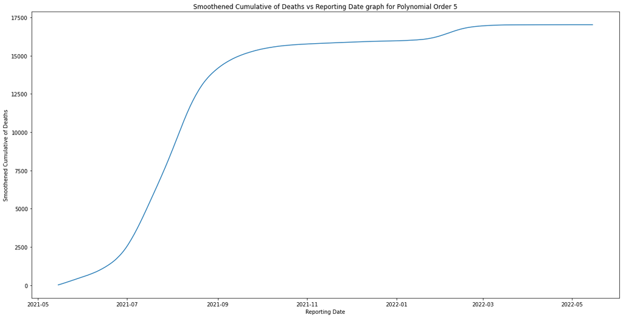

```python
c_list5=[] # assign an empty array of name c_list5(smoothened cumulative list)
y_hat5=[] # assign an empty array of name y_hat5(smoothened value)
y = 0  # variable y with value 0

for x in range(0,len(y1)): # for loop
    y = y + yhat2[x] # calculate Smoothened cumulative
    cr5 = math.trunc(y) # truncate and remove decimal points and round the value of Smoothened Cumulative
    c_list5.append(cr5) # insert the elements in the c_list5 array
    yhr5 = math.trunc(yhat2[x]) # truncate and remove decimal points and round the Smoothened Value
    y_hat5.append(yhr5) # insert the elements in the y_hat5 array

print('\nReporting Date      | Deaths (Last 24 Hours)  | Smoothened Value      | Smoothened Cumulative') # print heading
print('------------------------------------------------------------------------------------------------') # print broken line
smooth_table_output5 = "\n".join("{} |        {}               | {}                    | {}".format(a, b, c, d) for a, b, c, d in zip(x2, y2, y_hat5, c_list5)) # joining table
print(smooth_table_output5) # print smooth_table_output5 after joining
fig15, ax15 = plt.subplots(figsize = (20, 10)) # create a figure and axis
ax15.set_title('Smoothened Cumulative of Deaths vs Reporting Date graph for Polynomial Order 5') # set title
ax15.set_xlabel('Reporting Date') # label of x-axis
ax15.set_ylabel('Smoothened Cumulative of Deaths') # label of y-axis
plt.plot(x2,c_list5) # Plot Smoothened Cumulative vs Reporting Date graph
plt.show() # show graph
```

**Applying SIRD Model on Infected Smoothened Cumulative - Polynomial Order 3**

```
0.6947018950712889 0.9265290365365707
```

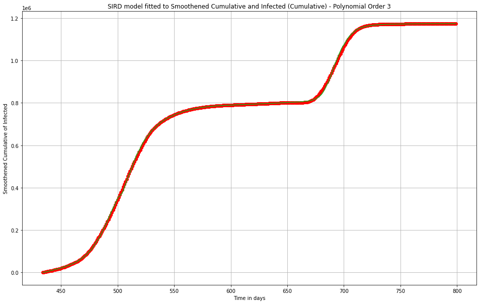

```python
ydata = c_list # assign c_list(infected smoothened cumulative list) into ydata variable
xdata = dataset['Days since the first case'] # assign Days since the first case column from dataset into xdata variable
ci = dataset['Infected (Cumulative)'] - 779000 # assign Infected (Cumulative) column from dataset into ci variable

ydata = np.array(ydata, dtype=float) # ydata array with type float
xdata = np.array(xdata, dtype=float) # xdata array with type float

#declaring the ODEs
def sird_model(y, x, beta, gamma, delta):
    S = -beta * y[0] * y[1] / N
    R = gamma * y[1]
    D = delta * y[1]
    I = -(S + R + D)
    return S, I, R, D

#integrating
def fit_odeint(x, beta, delta):
    return integrate.odeint(sird_model, (S0, I0, R0, D0), x, args=(beta, gamma, delta))[:,1]

#parameters
N = 1.0
I0 = ydata[0]
S0 = N - I0
R0 = 0.0
D0 = 0.0
gamma = 1.0/14.0

#fitting the model with data
popt, pcov = optimize.curve_fit(fit_odeint, xdata, ydata)
print(popt[0], popt[1])
fitted = fit_odeint(xdata, *popt)

#plotting the curves
plt.figure(figsize=[16.18,10]);
plt.grid() # show grid line on graph
plt.plot(xdata, ydata, 'ro') # plot Infected smoothened cumulative list vs Days since the first case graph
#plt.plot(xdata, fitted, 'xkcd:blue') # plot fitted vs Days since the first case graph with blue line
plt.plot(xdata, ci, 'xkcd:green') # plot Infected (Cumulative) vs Days since the first case graph with green line
#plt.xlim(475, 525) # zoom to x-axis from 475 to 525
#print(fitted)
plt.xlabel("Time in days") # label of x-axis
plt.ylabel("Smoothened Cumulative of Infected") # label of y-axis
plt.title("SIRD model fitted to Smoothened Cumulative and Infected (Cumulative) - Polynomial Order 3") # set title
plt.show() # show graph
```

**Applying SIRD Model on Infected Smoothened Cumulative - Polynomial Order 4**

```
0.7402796914957872 0.9235460965275595
```

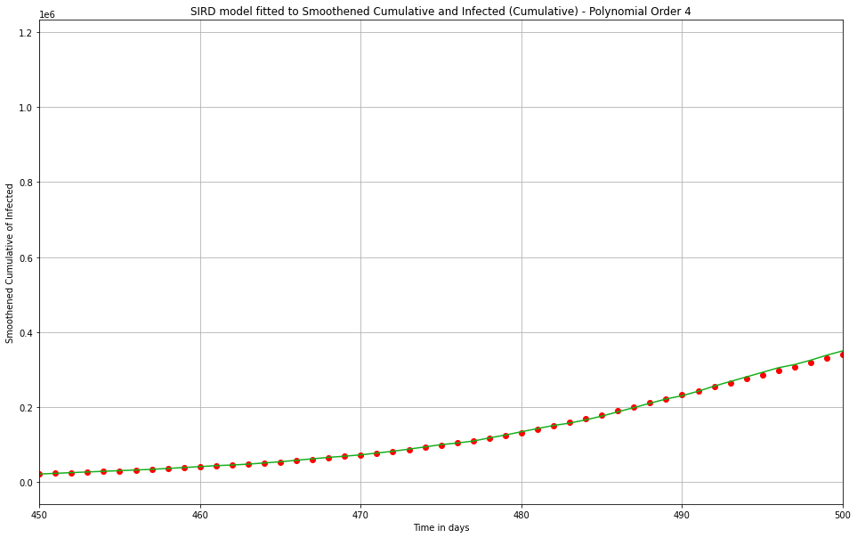

```python
ydata1 = c_list1 # assign c_list1(infected smoothened cumulative list) into ydata1 variable
xdata1 = dataset['Days since the first case'] # assign Days since the first case column from dataset into xdata1 variable
ci1 = dataset['Infected (Cumulative)'] - 779000 # assign Infected (Cumulative) column from dataset into ci1 variable

ydata1 = np.array(ydata1, dtype=float) # ydata1 array with type float
xdata1 = np.array(xdata1, dtype=float) # xdata1 array with type float

#declaring the ODEs
def sird_model(y, x, beta, gamma, delta):
    S = -beta * y[0] * y[1] / N
    R = gamma * y[1]
    D = delta * y[1]
    I = -(S + R + D)
    return S, I, R, D

#integrating
def fit_odeint(x, beta, delta):
    return integrate.odeint(sird_model, (S0, I0, R0, D0), x, args=(beta, gamma, delta))[:,1]

#parameters
N = 1.0
I0 = ydata1[0]
S0 = N - I0
R0 = 0.0
D0 = 0.0
gamma = 1.0/14.0

#fitting the model with data
popt, pcov = optimize.curve_fit(fit_odeint, xdata1, ydata1)
print(popt[0], popt[1])
fitted = fit_odeint(xdata1, *popt)

#plotting the curves
plt.figure(figsize=[16.18,10]);
plt.grid() # show grid line on graph
plt.plot(xdata1, ydata1, 'ro') # plot Infected smoothened cumulative list vs Days since the first case graph
#plt.plot(xdata1, fitted, 'xkcd:blue') # plot fitted vs Days since the first case graph with blue line
plt.plot(xdata1, ci1, 'xkcd:green') # plot Infected (Cumulative) vs Days since the first case graph with green line
plt.xlim(450, 500) # zoom to x-axis from 475 to 525
#print(fitted)
plt.xlabel("Time in days") # label of x-axis
plt.ylabel("Smoothened Cumulative of Infected") # label of y-axis
plt.title("SIRD model fitted to Smoothened Cumulative and Infected (Cumulative) - Polynomial Order 4") # set title
plt.show() # show graph
```

**Applying SIRD Model on Infected Smoothened Cumulative - Polynomial Order 5**

```
0.7238376452369207 0.9249625782515535
```

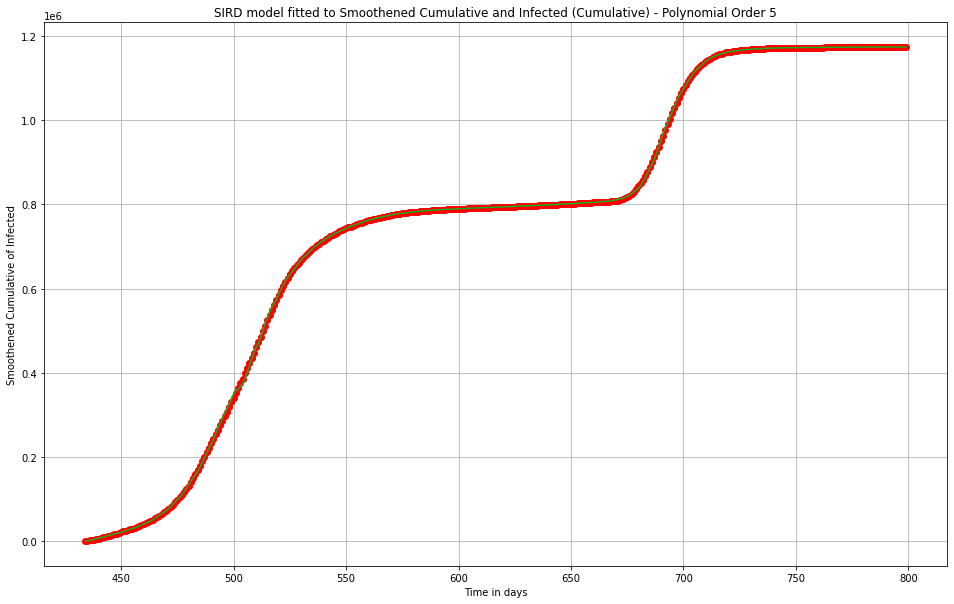

```python
ydata2 = c_list2 # assign c_list2(infected smoothened cumulative list) into ydata2 variable
xdata2 = dataset['Days since the first case'] # assign Days since the first case column from dataset into xdata2 variable
ci2 = dataset['Infected (Cumulative)'] - 779000 # assign Infected (Cumulative) column from dataset into ci2 variable

ydata2 = np.array(ydata2, dtype=float) # ydata2 array with type float
xdata2 = np.array(xdata2, dtype=float) # xdata2 array with type float

#declaring the ODEs
def sird_model(y, x, beta, gamma, delta):
    S = -beta * y[0] * y[1] / N
    R = gamma * y[1]
    D = delta * y[1]
    I = -(S + R + D)
    return S, I, R, D

#integrating
def fit_odeint(x, beta, delta):
    return integrate.odeint(sird_model, (S0, I0, R0, D0), x, args=(beta, gamma, delta))[:,1]

#parameters
N = 1.0
I0 = ydata2[0]
S0 = N - I0
R0 = 0.0
D0 = 0.0
gamma = 1.0/14.0

#fitting the model with data
popt, pcov = optimize.curve_fit(fit_odeint, xdata2, ydata2)
print(popt[0], popt[1])
fitted = fit_odeint(xdata2, *popt)

#plotting the curves
plt.figure(figsize=[16.18,10]);
plt.grid()  # show grid line on graph
plt.plot(xdata2, ydata2, 'ro') # plot Infected smoothened cumulative list vs Days since the first case graph
#plt.plot(xdata2, fitted, 'xkcd:blue') # plot fitted vs Days since the first case graph with blue line
plt.plot(xdata2, ci2, 'xkcd:green') # plot Infected (Cumulative) vs Days since the first case graph with green line
#plt.xlim(475, 525) # zoom to x-axis from 475 to 525
#print(fitted)
plt.xlabel("Time in days") # label of x-axis
plt.ylabel("Smoothened Cumulative of Infected") # label of y-axis
plt.title("SIRD model fitted to Smoothened Cumulative and Infected (Cumulative) - Polynomial Order 5") # set title
plt.show() # show graph
```

**Applying SIRD Model on Deaths Smoothened Cumulative - Polynomial Order 3**

```
0.8402436538183558 0.9184856761737171
```

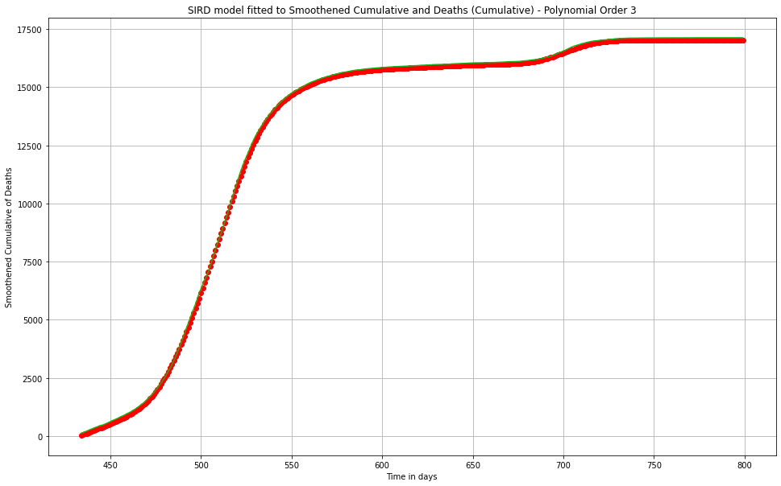

```python
ydata3 = c_list3 # assign c_list3(deaths smoothened cumulative list) into ydata3 variable
xdata3 = dataset['Days since the first case'] # assign Days since the first case column from dataset into xdata3 variable
cd = dataset['Deaths (Cumulative)'] - 12000 # assign Deaths (Cumulative) column from dataset into cd variable

ydata3 = np.array(ydata3, dtype=float) # ydata3 array with type float
xdata3 = np.array(xdata3, dtype=float) # xdata3 array with type float

#declaring the ODEs
def sird_model(y, x, beta, gamma, delta):
    S = -beta * y[0] * y[1] / N
    R = gamma * y[1]
    D = delta * y[1]
    I = -(S + R + D)
    return S, I, R, D

#integrating
def fit_odeint(x, beta, delta):
    return integrate.odeint(sird_model, (S0, I0, R0, D0), x, args=(beta, gamma, delta))[:,1]

#parameters
N = 1.0
I0 = ydata3[0]
S0 = N - I0
R0 = 0.0
D0 = 0.0
gamma = 1.0/14.0

#fitting the model with data
popt, pcov = optimize.curve_fit(fit_odeint, xdata3, ydata3)
print(popt[0], popt[1])
fitted = fit_odeint(xdata3, *popt)

#plotting the curves
plt.figure(figsize=[16.18,10]);
plt.grid() # show grid line on graph
plt.plot(xdata3, ydata3, 'ro') # plot deaths smoothened cumulative list vs Days since the first case graph
#plt.plot(xdata3, fitted, 'xkcd:blue') # plot fitted vs Days since the first case graph with blue line
plt.plot(xdata3, cd, 'xkcd:green') # plot Deaths (Cumulative) vs Days since the first case graph with green line
#plt.xlim(475, 525) # zoom to x-axis from 475 to 525
#print(fitted)
plt.xlabel("Time in days") # label of x-axis
plt.ylabel("Smoothened Cumulative of Deaths") # label of y-axis
plt.title("SIRD model fitted to Smoothened Cumulative and Deaths (Cumulative) - Polynomial Order 3") # set title
plt.show() # show graph
```

**Applying SIRD Model on Deaths Smoothened Cumulative - Polynomial Order 4**

```
0.8409542126310197 0.917302480620765
```

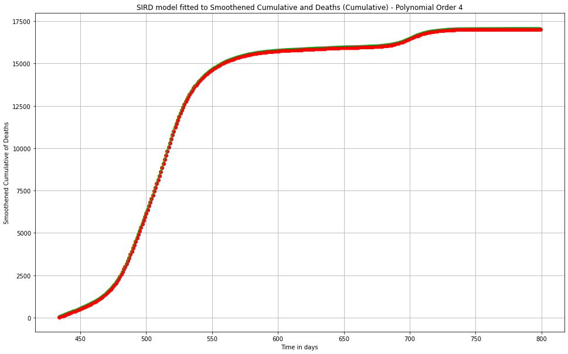

```python
ydata4 = c_list4 # assign c_list4(deaths smoothened cumulative list) into ydata4 variable
xdata4 = dataset['Days since the first case'] # assign Days since the first case column from dataset into xdata4 variable
cd1 = dataset['Deaths (Cumulative)'] - 12000 # assign Deaths (Cumulative) column from dataset into cd1 variable

ydata4 = np.array(ydata4, dtype=float) # ydata4 array with type float
xdata4 = np.array(xdata4, dtype=float) # xdata4 array with type float

#declaring the ODEs
def sird_model(y, x, beta, gamma, delta):
    S = -beta * y[0] * y[1] / N
    R = gamma * y[1]
    D = delta * y[1]
    I = -(S + R + D)
    return S, I, R, D

#integrating
def fit_odeint(x, beta, delta):
    return integrate.odeint(sird_model, (S0, I0, R0, D0), x, args=(beta, gamma, delta))[:,1]

#parameters
N = 1.0
I0 = ydata4[0]
S0 = N - I0
R0 = 0.0
D0 = 0.0
gamma = 1.0/14.0

#fitting the model with data
popt, pcov = optimize.curve_fit(fit_odeint, xdata4, ydata4)
print(popt[0], popt[1])
fitted = fit_odeint(xdata4, *popt)

#plotting the curves
plt.figure(figsize=[16.18,10]);
plt.grid() # show grid line on graph
plt.plot(xdata4, ydata4, 'ro') # plot deaths smoothened cumulative list vs Days since the first case graph
#plt.plot(xdata4, fitted, 'xkcd:blue') # plot fitted vs Days since the first case graph with blue line
plt.plot(xdata4, cd1, 'xkcd:green') # plot Deaths (Cumulative) vs Days since the first case graph with green line
#plt.xlim(475, 525) # zoom to x-axis from 475 to 525
#print(fitted)
plt.xlabel("Time in days") # label of x-axis
plt.ylabel("Smoothened Cumulative of Deaths") # label of y-axis
plt.title("SIRD model fitted to Smoothened Cumulative and Deaths (Cumulative) - Polynomial Order 4") # set title
plt.show() # show graph
```

**Applying SIRD Model on Deaths Smoothened Cumulative - Polynomial Order 5**

```
0.8419430167014103 0.9171012480806657
```

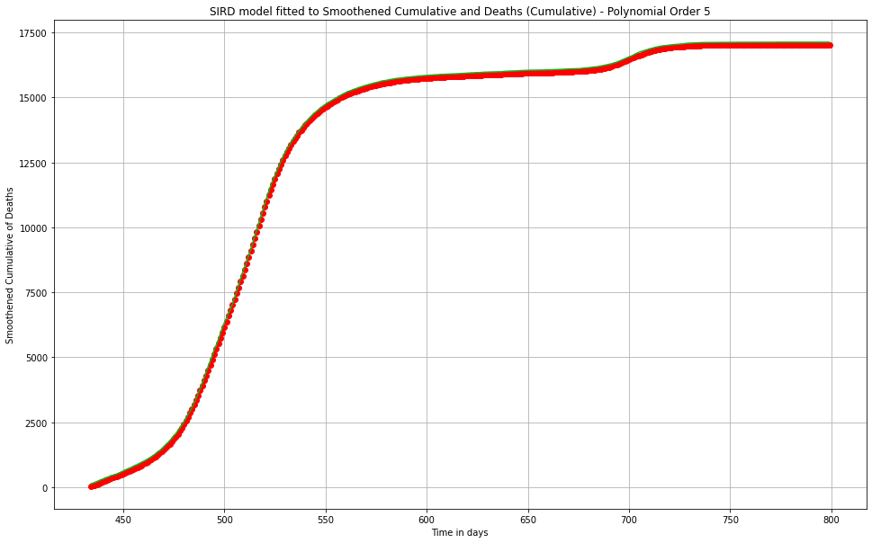

```python
ydata5 = c_list5 # assign c_list5(deaths smoothened cumulative list) into ydata5 variable
xdata5 = dataset['Days since the first case'] # assign Days since the first case column from dataset into xdata5 variable
cd2 = dataset['Deaths (Cumulative)'] - 12000 # assign Deaths (Cumulative) column from dataset into cd2 variable

ydata5 = np.array(ydata5, dtype=float) # ydata5 array with type float
xdata5 = np.array(xdata5, dtype=float) # xdata5 array with type float

#declaring the ODEs
def sird_model(y, x, beta, gamma, delta):
    S = -beta * y[0] * y[1] / N
    R = gamma * y[1]
    D = delta * y[1]
    I = -(S + R + D)
    return S, I, R, D

#integrating
def fit_odeint(x, beta, delta):
    return integrate.odeint(sird_model, (S0, I0, R0, D0), x, args=(beta, gamma, delta))[:,1]

#parameters
N = 1.0
I0 = ydata5[0]
S0 = N - I0
R0 = 0.0
D0 = 0.0
gamma = 1.0/14.0

#fitting the model with data
popt, pcov = optimize.curve_fit(fit_odeint, xdata5, ydata5)
print(popt[0], popt[1])
fitted = fit_odeint(xdata5, *popt)

#plotting the curves
plt.figure(figsize=[16.18,10]);
plt.grid() # show grid line on graph
plt.plot(xdata5, ydata5, 'ro') # plot deaths smoothened cumulative list vs Days since the first case graph
#plt.plot(xdata5, fitted, 'xkcd:blue') # plot fitted vs Days since the first case graph with blue line
plt.plot(xdata5, cd2, 'xkcd:green') # plot Deaths (Cumulative) vs Days since the first case graph with green line
#plt.xlim(475, 525) # zoom to x-axis from 475 to 525
#print(fitted)
plt.xlabel("Time in days") # label of x-axis
plt.ylabel("Smoothened Cumulative of Deaths") # label of y-axis
plt.title("SIRD model fitted to Smoothened Cumulative and Deaths (Cumulative) - Polynomial Order 5") # set title
plt.show() # show graph
```